# Proyecto 4 · Sistema de recomendación para un marketplace farmacéutico

R Markdown reproducible con las fases 1 a 7

Equipo · Estadística Industrial 2026-II

2026-11-22

# Cómo está organizado este documento

Este es el entregable reproducible del Proyecto 4. Ejecuta, en orden, las siete fases del enunciado. Cada fase también existe como documento independiente en la misma carpeta, por si se quiere revisar una sola.

| Fase | Archivo | Qué produce | Qué guarda en `data/` |
| --- | --- | --- | --- |
| 1 | `fase1_tutorial.Rmd` | Tutorial de Ander Fernández reproducido con Book-Crossing (Kaggle), comentado línea a línea, con los dos errores corregidos | archivos descomprimidos de `archive.zip` |
| 2 | `fase2_datos.Rmd` | Lectura en Latin-1, unión por `invoice`, resumen descriptivo | `datos_unidos.rds`, `catalogo.rds` |
| 3 | `fase3_matriz.Rmd` | Cuatro definiciones de preferencia, dispersión, elección de log(1 + cantidad) | `matriz_usuario_producto.rds` |
| 4 | `fase4_coseno.Rmd` | Función de coseno validada contra `lsa::cosine`, matriz 732 × 732 | `similitud_productos.rds` |
| 5 | `fase5_item.Rmd` | `item_recommendation()` y casos con criterio farmacéutico | `recomendaciones_item.rds` |
| 6 | `fase6_usuario.Rmd` | `user_recommendation()`, verificación de exclusión, sensibilidad a k y umbral | `recomendaciones_usuario.rds` |
| 7 | `fase7_evaluacion.Rmd` | Partición temporal, hit rate@10 y precision@10 con IC frente a la línea base | (nada) |

**Para generarlo:** abrir este archivo en RStudio desde la carpeta `proyecto4` y presionar **Knit**. La carpeta debe tener `archive.zip` (Kaggle) y `data/pro2.csv`, `data/cab.csv`. Tarda alrededor de 15 minutos (la Fase 6 sola toma unos 9) y necesita los paquetes `dplyr`, `tidyr`, `readr`, `ggplot2`, `cluster`, `lsa`, `rmarkdown` y `knitr`.

```
## Generado con R version 4.6.1 (2026-06-24 ucrt) el 22/11/2026 12:57
```

# 1 Fase 1 · Reproducir el tutorial con Book-Crossing (Kaggle)

Este documento reproduce el tutorial «Cómo programar un sistema de recomendación en R» de Ander Fernández con la versión de Book-Crossing publicada en Kaggle. Cada bloque de código está comentado línea a línea y, al final de cada sección, se explica **qué hace** y **qué supuesto hace sobre los datos**. Las diferencias con el tutorial original y los cambios están marcados así:

- **Cambio:** ajuste necesario por usar los datos de Kaggle.
- **Error:** fallo real del código, que mostramos con el original al lado del corregido (hay dos: `recomendar()` e `item_recommendation()`).
- **Nota de interpretación:** el código funciona, pero su resultado hay que leerlo con cuidado.

## 1.1 Lectura de los datos

```r
unzip("archive.zip", exdir = "data")            # descomprime el zip de Kaggle en la carpeta data/

# Cambio: el tutorial tomaba los archivos por posición, files[1], files[2], files[3], después
# de list.files("data"). En nuestra carpeta data/ también están pro2.csv y cab.csv de la
# farmacia, así que el orden alfabético ya no da Books, Ratings, Users. Los leemos por nombre.
books   = read.csv("data/Books.csv",   sep = ";")   # libros: ISBN, Title, Author, Year, Publisher
ratings = read.csv("data/Ratings.csv", sep = ";")   # calificaciones: User-ID, ISBN, Rating
users   = read.csv("data/Users.csv",   sep = ";")   # usuarios: User-ID, Age
```

**¿Qué cambió al pasar del archivo original al de Kaggle?**

|  | Original (U. de Friburgo) | Kaggle (este proyecto) |
| --- | --- | --- |
| Archivos | `BX-Books.csv`, `BX-Book-Ratings.csv`, `BX-Users.csv` | `Books.csv`, `Ratings.csv`, `Users.csv` |
| Codificación | Latin-1 | UTF-8 |
| Columnas de libros | `Book-Title`, `Book-Author`, `Year-Of-Publication`, `Publisher` y tres URL de carátula | `Title`, `Author`, `Year`, `Publisher` (sin URL de carátula) |
| Columna de calificación | `Book-Rating` | `Rating` |
| Usuarios | `User-ID`, `Location`, `Age` | `User-ID`, `Age` (sin `Location`) |

- `read.csv()` convierte los guiones de los nombres en puntos, así que `User-ID` queda como `User.ID`, que es el nombre que usa el resto del código.
- El código usa `Author`, `Publisher` y `Rating`, que ya coinciden con Kaggle; con el archivo original habría que renombrar `Book.Author` y `Book.Rating`.
- Kaggle no trae las URL de carátula, así que la parte del tutorial que descarga las imágenes con `readJPEG` no se puede reproducir. En el proyecto de la farmacia esa parte la reemplazan las tarjetas del prototipo.
- Verificamos que la lectura no se dañó con comillas dentro de los títulos: el número de filas leídas debe ser el número de líneas del archivo menos el encabezado.

```r
c(libros = nrow(books), calificaciones = nrow(ratings), usuarios = nrow(users))
```

```
##         libros calificaciones       usuarios
##         271379        1149780         278859
```

```r
c(lineas_books = length(readLines("data/Books.csv", encoding = "UTF-8")) - 1)
```

```
## lineas_books
##       271379
```

## 1.2 Exploración de los datos

```r
glimpse(ratings)   # 3 columnas: usuario (entero), ISBN (texto) y calificación de 0 a 10
```

```
## Rows: 1,149,780
## Columns: 3
## $ User.ID <int> 276725, 276726, 276727, 276729, 276729, 276733, 276736, 276737…
## $ ISBN    <chr> "034545104X", "0155061224", "0446520802", "052165615X", "05217…
## $ Rating  <int> 0, 5, 0, 3, 6, 0, 8, 6, 7, 10, 0, 0, 0, 0, 0, 0, 9, 0, 0, 9, 8…
```

```r
glimpse(books)
```

```
## Rows: 271,379
## Columns: 5
## $ ISBN      <chr> "0195153448", "0002005018", "0060973129", "0374157065", "039…
## $ Title     <chr> "Classical Mythology", "Clara Callan", "Decision in Normandy…
## $ Author    <chr> "Mark P. O. Morford", "Richard Bruce Wright", "Carlo D'Este"…
## $ Year      <int> 2002, 2001, 1991, 1999, 1999, 1991, 2000, 1993, 1996, 2002, …
## $ Publisher <chr> "Oxford University Press", "HarperFlamingo Canada", "HarperP…
```

```r
glimpse(users)
```

```
## Rows: 278,859
## Columns: 2
## $ User.ID <chr> "1", "2", "3", "4", "5", "6", "7", "8", "9", "10", "11", "12",…
## $ Age     <chr> "", "18", "", "17", "", "61", "", "", "", "26", "14", "", "26"…
```

### 1.2.1 Categorías aleatorias

Book-Crossing no trae género literario. Para tener una tercera variable de contenido, el tutorial **inventa** una categoría al azar. Es solo didáctico: como la categoría no tiene relación con el libro, cualquier similitud que dependa de ella es ruido.

```r
set.seed(1234)                                   # semilla para que el sorteo sea reproducible
categories = c("Action and Adventure", "Classic", "Detective and Mystery", "Fantasy")
books$category = sample(categories, nrow(books), # a cada libro le asigna una categoría al azar
                        replace = TRUE,          # con reemplazo: las categorías se repiten
                        prob = c(0.25, 0.3, 0.25, 0.20))  # con estas probabilidades
books$category = as.factor(books$category)       # la guarda como factor (variable categórica)

rm(categories)
table(books$category)
```

```
##
##  Action and Adventure               Classic Detective and Mystery
##                 67939                 81456                 67857
##               Fantasy
##                 54127
```

### 1.2.2 Formato de los identificadores

```r
books$ISBN       = paste0("Isbn.", books$ISBN)        # antepone un prefijo de texto a cada ID
users$User.ID    = paste0("User.", users$User.ID)     # para que R los trate como nombres y no
ratings$ISBN     = paste0("Isbn.", ratings$ISBN)      # como números (así pueden ser nombres
ratings$User.ID  = paste0("User.", ratings$User.ID)   # de filas y columnas de una matriz)
```

### 1.2.3 Distribución de las calificaciones

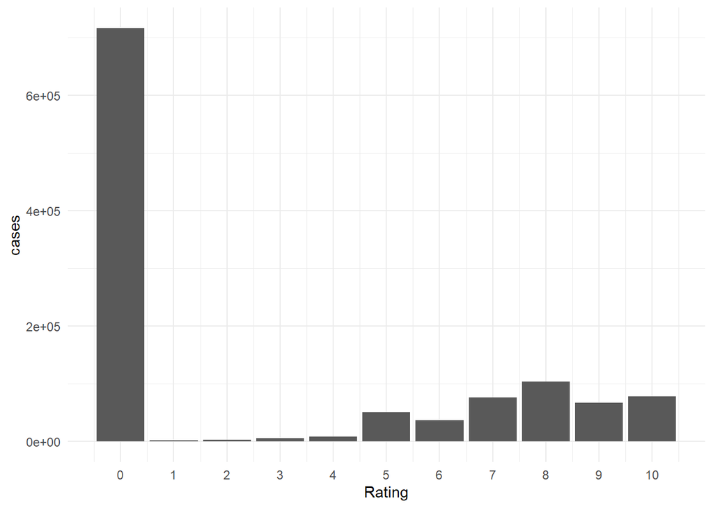

```r
library(ggplot2)

ratings %>%
  group_by(Rating) %>%                         # agrupa por valor de calificación
  summarize(cases = n()) %>%                   # cuenta cuántas calificaciones hay de cada valor
  ggplot(aes(Rating, cases)) + geom_col() +    # gráfico de barras
  theme_minimal() + scale_x_continuous(breaks = 0:10)
```

La mayoría de las calificaciones son 0. En Book-Crossing un 0 es una **calificación implícita**: el usuario interactuó con el libro pero no lo puntuó. No significa “no me gustó”.

```r
ratings = ratings[ratings$Rating != 0, ]   # se quedan solo las calificaciones explícitas (1 a 10)
```

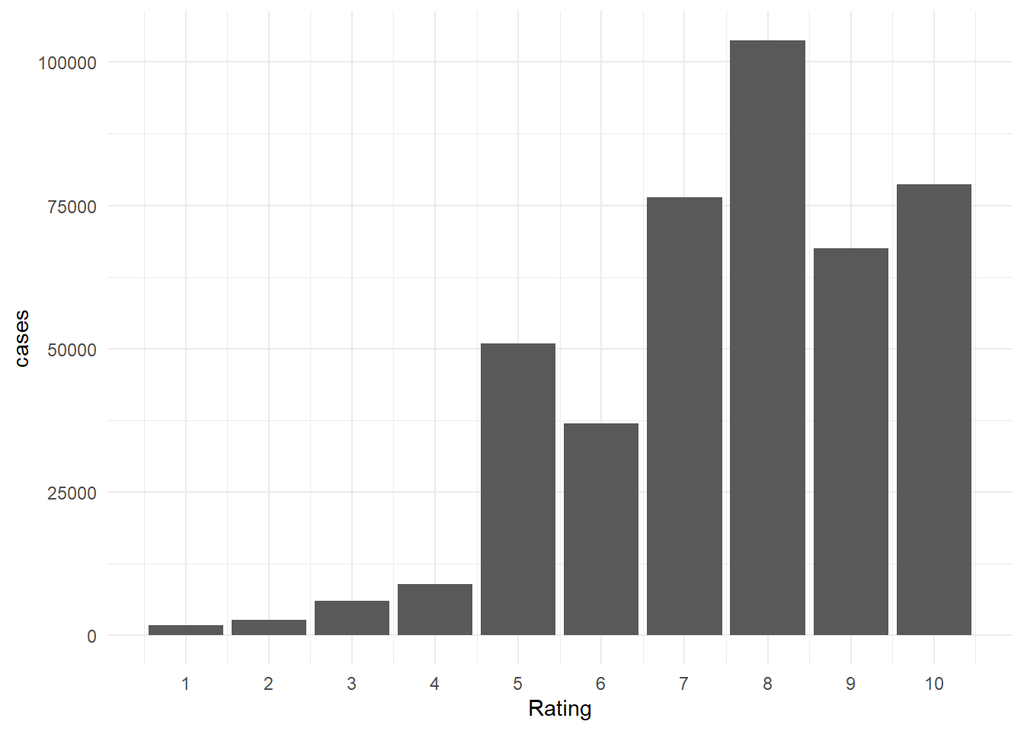

```r
ratings %>%
  group_by(Rating) %>%
  summarize(cases = n()) %>%
  ggplot(aes(Rating, cases)) + geom_col() +
  theme_minimal() + scale_x_continuous(breaks = 0:10)
```

Sin los ceros, las calificaciones se concentran entre 5 y 10: los usuarios casi solo puntúan lo que les gustó.

### 1.2.4 Calificaciones por usuario

```r
ratings_sum = ratings %>%
  group_by(User.ID) %>%     # una fila por usuario
  count()                   # número de calificaciones de cada usuario

summary(ratings_sum$n)
```

```
##     Min.  1st Qu.   Median     Mean  3rd Qu.     Max.
##    1.000    1.000    1.000    5.574    3.000 8524.000
```

Al menos el 75 % de los usuarios ha calificado 3 libros o menos. Con tan poca información no se puede encontrar a quién se parecen, así que el tutorial se queda con los usuarios que tienen **más de 4** calificaciones. Eso también reduce el cálculo.

```r
user_index = ratings_sum$User.ID[ratings_sum$n > 4]       # usuarios con 5 o más calificaciones

users   = users[users$User.ID %in% user_index, ]          # filtra las tres tablas a esos usuarios
ratings = ratings[ratings$User.ID %in% user_index, ]
books   = books[books$ISBN %in% ratings$ISBN, ]           # y a los libros que ellos calificaron

rm(ratings_sum, user_index)

c(usuarios = nrow(users), calificaciones = nrow(ratings), libros = nrow(books))
```

```
##       usuarios calificaciones         libros
##          14220         340341         132831
```

**Supuesto:** los usuarios con pocas calificaciones no aportan a la similitud. La consecuencia es que el sistema no sabe qué recomendarle a un usuario nuevo (el problema del “arranque en frío”).

Nota: hay calificaciones de ISBN que no están en la tabla de libros, así que el número de libros es menor que el de ISBN distintos en `ratings`.

```r
c(isbn_en_ratings = n_distinct(ratings$ISBN),
  isbn_con_ficha  = sum(unique(ratings$ISBN) %in% books$ISBN))
```

```
## isbn_en_ratings  isbn_con_ficha
##          159357          132830
```

## 1.3 Recomendador basado en contenido

### 1.3.1 Disimilitud de Gower

Este recomendador compara libros por sus **características** (autor, editorial, categoría), no por quién los leyó. Como todas son categóricas, se usa la distancia de Gower de `cluster::daisy()`: para cada variable vale 0 si los dos libros coinciden y 1 si no, y luego se promedia (con pesos, si se dan).

El tutorial intenta primero calcularla para todos los libros. **No lo ejecutamos** (`eval = FALSE`): con 132.831 libros la matriz tendría 132.831² celdas, unos 141 GB, y el equipo se queda sin memoria. Ese es justamente el punto que el tutorial quiere mostrar.

```r
library(cluster)

books_distance = books[, c("ISBN", "Author", "Publisher")]
books_distance[, 1] <- as.factor(books_distance[, 1])     # daisy necesita factores, no texto
books_distance[, 2] <- as.factor(books_distance[, 2])
books_distance[, 3] <- as.factor(books_distance[, 3])

dissimilarity = daisy(books_distance, metric = "gower")   # demasiado grande: no se ejecuta
matrix(ncol = nrow(books), nrow = nrow(books))            # ilustra el tamaño de la matriz
```

**Cambio:** el original escribía el número de libros fijo (`115246`); aquí se usa `nrow(books)`, porque con Kaggle el número cambia.

Por eso el tutorial se queda con **10.000 libros** y da pesos a las variables: el autor pesa 2, la editorial 0,5 y la categoría 1. Así dos libros se parecen más por tener el mismo autor que por tener la misma editorial.

```r
library(cluster)

book_feature = books[1:10000, c("Author", "Publisher", "category")]  # primeros 10.000 libros

book_feature[, 1] <- as.factor(book_feature[, 1])
book_feature[, 2] <- as.factor(book_feature[, 2])
book_feature[, 3] <- as.factor(book_feature[, 3])

dissimilarity = daisy(book_feature, metric = "gower",
                      weights = c(2, 0.5, 1))      # pesos: autor, editorial, categoría
dissimilarity = as.matrix(dissimilarity)          # objeto dist → matriz 10.000 × 10.000

row.names(dissimilarity) <- books$ISBN[1:10000]   # filas y columnas con el ISBN de cada libro
colnames(dissimilarity)  <- books$ISBN[1:10000]

dissimilarity[15:20, 15:20]
```

```
##                 Isbn.0452264464 Isbn.0609804618 Isbn.1841721522 Isbn.0439095026
## Isbn.0452264464       0.0000000       1.0000000       1.0000000       0.7142857
## Isbn.0609804618       1.0000000       0.0000000       0.7142857       1.0000000
## Isbn.1841721522       1.0000000       0.7142857       0.0000000       1.0000000
## Isbn.0439095026       0.7142857       1.0000000       1.0000000       0.0000000
## Isbn.0971880107       1.0000000       0.7142857       0.7142857       1.0000000
## Isbn.0345402871       1.0000000       1.0000000       1.0000000       1.0000000
##                 Isbn.0971880107 Isbn.0345402871
## Isbn.0452264464       1.0000000               1
## Isbn.0609804618       0.7142857               1
## Isbn.1841721522       0.7142857               1
## Isbn.0439095026       1.0000000               1
## Isbn.0971880107       0.0000000               1
## Isbn.0345402871       1.0000000               0
```

**Nota de interpretación (texto del tutorial):** dice que se toman los libros “de los autores más comunes”, pero `books[1:10000, ]` toma simplemente las primeras 10.000 filas del archivo.

Con pesos 2, 0,5 y 1 (suma 3,5), los únicos valores posibles de disimilitud son:

```r
w = c(autor = 2, editorial = 0.5, categoria = 1)
combinaciones = expand.grid(autor = 0:1, editorial = 0:1, categoria = 0:1)  # 1 = no coincide
combinaciones$disimilitud = round(as.matrix(combinaciones) %*% w / sum(w), 3)
combinaciones[order(combinaciones$disimilitud), ]
```

```
##   autor editorial categoria disimilitud
## 1     0         0         0       0.000
## 3     0         1         0       0.143
## 5     0         0         1       0.286
## 7     0         1         1       0.429
## 2     1         0         0       0.571
## 4     1         1         0       0.714
## 6     1         0         1       0.857
## 8     1         1         1       1.000
```

```r
sort(unique(round(as.vector(dissimilarity), 3)))   # coinciden con los que aparecen en la matriz
```

```
## [1] 0.000 0.143 0.286 0.429 0.571 0.714 0.857 1.000
```

De ahí sale el orden de las reglas del tutorial: primero mismo autor, editorial y categoría (0), luego mismo autor y categoría (0,14), luego solo mismo autor (0,43), etc.

### 1.3.2 Recomendaciones para un usuario

```r
user_id = "User.1167"

user_books = ratings %>%
  filter(User.ID == user_id & ISBN %in% books$ISBN[1:10000]) %>%  # libros de este usuario que
  arrange(desc(Rating))                                           # están entre los 10.000

head(user_books, 10)
```

```
##     User.ID            ISBN Rating
## 1 User.1167 Isbn.0060929596     10
## 2 User.1167 Isbn.0802135196      9
## 3 User.1167 Isbn.0440224675      8
## 4 User.1167 Isbn.0679450548      7
## 5 User.1167 Isbn.0743230213      7
## 6 User.1167 Isbn.0373834985      5
## 7 User.1167 Isbn.038533656X      5
## 8 User.1167 Isbn.0440217520      5
```

La idea es recomendar libros parecidos a los que el usuario leyó, **ponderando** por su calificación: un libro parecido a uno que calificó con 10 vale más que uno parecido a uno que calificó con 5. La puntuación es `similitud × calificación`, con `similitud = 1 − disimilitud`.

```r
library(tidyr)

books$ISBN = as.character(books$ISBN)
selected_books = user_books[, c("ISBN", "Rating")]    # libros leídos y su calificación

recomendar = function(selected_books, dissimilarity_matrix,
                      books, n_recommendations = 5){

  # columnas de la matriz que corresponden a los libros que leyó el usuario
  selected_book_indexes = which(colnames(dissimilarity_matrix) %in% selected_books$ISBN)

  # tabla ancha: una fila por libro candidato, una columna por libro leído
  results = data.frame(dissimilarity_matrix[, selected_book_indexes],
                       recommended_book = row.names(dissimilarity_matrix),
                       stringsAsFactors = FALSE)

  recomendaciones = results %>%
    pivot_longer(cols = c(-"recommended_book"),        # a formato largo: un par
                 names_to = "readed_book",             # (candidato, libro leído) por fila
                 values_to = "dissimilarity") %>%
    left_join(selected_books,                          # ERROR 1 corregido: calificación
              by = c("readed_book" = "ISBN")) %>%      # del libro LEÍDO (ver abajo)
    filter(recommended_book != readed_book) %>%        # un libro no se recomienda a sí mismo
    filter(!(recommended_book %in% selected_books$ISBN)) %>%  # ni uno ya leído
    filter(!is.na(Rating)) %>%
    mutate(similarity = 1 - dissimilarity,             # similitud entre 0 y 1
           weighted_score = similarity * Rating) %>%   # ponderada por la calificación
    filter(weighted_score > 0) %>%
    group_by(recommended_book) %>%
    slice_max(weighted_score, n = 1, with_ties = FALSE) %>%  # mejor puntuación de cada candidato
    ungroup() %>%
    slice_max(weighted_score, n = n_recommendations,   # los N mejores
              with_ties = FALSE) %>%
    left_join(books, by = c("recommended_book" = "ISBN"))   # añade título, autor, etc.

  return(recomendaciones)
}

recomendaciones = recomendar(selected_books, dissimilarity, books)
recomendaciones %>% select(recommended_book, readed_book, similarity, Rating,
                           weighted_score, Title, Author, Publisher, category)
```

```
## # A tibble: 5 × 9
##   recommended_book readed_book     similarity Rating weighted_score Title Author
##   <chr>            <chr>                <dbl>  <int>          <dbl> <chr> <chr>
## 1 Isbn.0060192119  Isbn.0060929596      0.857     10           8.57 As N… John …
## 2 Isbn.0440206154  Isbn.0440224675      1          8           8    Red … Thoma…
## 3 Isbn.2266051326  Isbn.0440224675      0.857      8           6.86 Le S… Thoma…
## 4 Isbn.1573228745  Isbn.0679450548      0.857      7           6    Inno… Jane …
## 5 Isbn.0440206146  Isbn.0440224675      0.714      8           5.71 Blac… Thoma…
## # ℹ 2 more variables: Publisher <chr>, category <fct>
```

### 1.3.3 Error 1 · `recomendar()` recomendaba libros ya leídos

Este es un **error real** del código: cambia el resultado. Original y corregido, lado a lado (solo cambia el centro de la tubería):

**Original**

```r
pivot_longer(...) %>%
  left_join(selected_books,
    by = c("recommended_book" = "ISBN")) %>%
  arrange(desc(dissimilarity)) %>%
  filter(recommended_book != readed_book) %>%
  filter(!is.na(Rating)) %>%
  mutate(...) %>%
  arrange(desc(weighted_score)) %>%
  filter(weighted_score > 0) %>%
  group_by(recommended_book) %>% slice(1) %>%
  top_n(n_recommendations, weighted_score)
```

**Corregido**

```r
pivot_longer(...) %>%
  left_join(selected_books,
    by = c("readed_book" = "ISBN")) %>%
  filter(recommended_book != readed_book) %>%
  filter(!(recommended_book %in%
           selected_books$ISBN)) %>%
  filter(!is.na(Rating)) %>%
  mutate(...) %>%
  filter(weighted_score > 0) %>%
  group_by(recommended_book) %>%
  slice_max(weighted_score, n = 1) %>%
  ungroup() %>%
  slice_max(weighted_score, n = n_recommendations)
```

**Por qué cambió cada línea:**

- **`by = c("readed_book" = "ISBN")`.** La calificación que pondera la similitud es la que el usuario le dio al libro que **leyó**. El original la pegaba al libro **recomendado**. Como después exige `!is.na(Rating)`, solo sobreviven los candidatos que tienen calificación, es decir, los que el usuario **ya leyó**. Lo comprobamos ejecutando la versión original:

```r
results = data.frame(dissimilarity[, colnames(dissimilarity) %in% selected_books$ISBN],
                     recommended_book = row.names(dissimilarity), stringsAsFactors = FALSE)
version_original = results %>%
  pivot_longer(cols = c(-"recommended_book"), names_to = "readed_book",
               values_to = "dissimilarity") %>%
  left_join(selected_books, by = c("recommended_book" = "ISBN")) %>%
  filter(recommended_book != readed_book, !is.na(Rating))

c(candidatos_original = n_distinct(version_original$recommended_book),
  de_ellos_ya_leidos  = sum(unique(version_original$recommended_book) %in% selected_books$ISBN))
```

```
## candidatos_original  de_ellos_ya_leidos
##                   8                   8
```

- **Filtro de libros ya leídos.** Con la unión corregida ya no hace falta para que el resultado sea correcto en este caso, pero lo dejamos explícito: es la regla de negocio (“no recomendar lo que ya tiene”) y así no depende de un efecto secundario de la unión.
- **`slice(1)` → `slice_max(weighted_score, n = 1)`.** `slice(1)` toma la primera fila de cada grupo y solo es la mejor porque antes se ordenó. `slice_max` lo dice directamente.
- **`top_n` → `ungroup()` + `slice_max(..., n = n_recommendations)`.** En el original, `top_n` se aplicaba **dentro de cada grupo** (seguía agrupado por libro), así que no limitaba a N recomendaciones. Además `top_n` devuelve filas de más cuando hay empates.
- Los dos `arrange()` intermedios se quitaron porque `slice_max` ya ordena.

**Supuestos de este recomendador:** que autor, editorial y categoría describen bien un libro (la categoría es aleatoria, así que aquí no aporta nada real), y que si a alguien le gustó un libro le gustarán los que se le parecen.

## 1.4 Recomendador colaborativo basado en ítems

### 1.4.1 Matriz usuario–producto

Aquí ya no se usan las características del libro sino **quién lo calificó**. La base es la matriz usuario–producto: una fila por usuario, una columna por libro y la calificación en la celda.

```r
rm(dissimilarity, book_feature, results)             # Cambio: libera ~3 GB de la parte de contenido,
invisible(gc())                                      # que ya no se usa; así basta con menos RAM

user_item = ratings %>%
  top_n(10000) %>%                                   # ver nota abajo
  pivot_wider(names_from = ISBN, values_from = Rating) %>%   # ISBN pasan a ser columnas
  as.data.frame()

row.names(user_item) = user_item$User.ID             # el usuario pasa a ser el nombre de fila
user_item$User.ID = NULL

user_item = as.matrix(user_item)                     # data.frame → matriz numérica

dim(user_item)
```

```
## [1]  8525 42151
```

```r
user_item[1:5, 1:5]
```

```
##             Isbn.0060096195 Isbn.0142302198 Isbn.038076041X Isbn.0699854289
## User.276822              10              10              10              10
## User.276847              NA              NA              NA              NA
## User.276859              NA              NA              NA              NA
## User.276861              NA              NA              NA              NA
## User.276872              NA              NA              NA              NA
##             Isbn.0786817070
## User.276822              10
## User.276847              NA
## User.276859              NA
## User.276861              NA
## User.276872              NA
```

**Nota de interpretación sobre `top_n(10000)` (no es un error).** El código hace lo que dice y funciona, pero conviene saber qué produce. Sin decir columna, `top_n()` ordena por la última (`Rating`) y conserva todas las filas empatadas. Como hay más de 10.000 calificaciones de 10, el resultado son **todas las calificaciones de 10**:

```r
table(ratings %>% top_n(10000) %>% pull(Rating))
```

```
##
##    10
## 64887
```

Es decir, la matriz solo tiene valores 10 o `NA`: en la práctica es una matriz **binaria** (“le encantó / no hay dato”). No lo corregimos: lo dejamos como en el tutorial porque reduce el tamaño y es una decisión de diseño válida, pero hay que tenerlo en cuenta al interpretar: en esta matriz, el coseno solo mide cuántos libros favoritos comparten dos usuarios.

### 1.4.2 Dispersión

```r
sum(is.na(user_item)) / (ncol(user_item) * nrow(user_item))   # proporción de celdas vacías
```

```
## [1] 0.9998194
```

Casi todas las celdas están vacías: cada usuario calificó unos pocos libros entre miles.

### 1.4.3 Similitud de coseno

$$\cos(A, B) = \frac{\sum_i A_i
B_i}{\sqrt{\sum_i A_i^2}\,\sqrt{\sum_i B_i^2}}$$

Mide el ángulo entre dos vectores: 1 si apuntan en la misma dirección, 0 si no comparten nada.

```r
cos_similarity = function(A, B){
  num = sum(A * B, na.rm = T)                                    # producto punto
  den = sqrt(sum(A^2, na.rm = T)) * sqrt(sum(B^2, na.rm = T))    # producto de las normas
  result = num / den
  return(result)
}
```

**Supuesto:** con `na.rm = TRUE` los `NA` cuentan como 0, es decir, “no calificó” se trata igual que “calificación cero” en el producto punto.

### 1.4.4 Función de recomendación por ítem

En lugar de calcular la matriz libro–libro completa, la función calcula la similitud de un solo libro contra todos los demás.

### 1.4.5 Error 2 · `item_recommendation()` buscaba el libro en las filas

Este también es un **error real**: con el código original la función no puede devolver recomendaciones válidas.

**Original**

```r
user_index = which(
  rownames(rating_matrix) == book_id)

similarity = apply(rating_matrix, 2,
  FUN = function(y) cos_similarity(
    rating_matrix[user_index, ], y))

tibble(ISBN = names(similarity),
       similarity = similarity) %>%
  filter(ISBN != book_id) %>%
  top_n(n_recommendations, similarity) %>%
  arrange(desc(similarity))
```

**Corregido**

```r
book_index = which(
  colnames(rating_matrix) == book_id)

similarity = apply(rating_matrix, 2,
  FUN = function(y) cos_similarity(
    rating_matrix[, book_index], y))

tibble(ISBN = names(similarity),
       similarity = similarity) %>%
  filter(ISBN != book_id) %>%
  slice_max(similarity, n = n_recommendations,
            with_ties = FALSE) %>%
  arrange(desc(similarity))
```

**Por qué cambió cada línea:**

- **`rownames` → `colnames`.** En `user_item` las filas son usuarios y las columnas libros. Buscar un ISBN entre los nombres de fila nunca lo encuentra y devuelve un índice vacío.
- **`rating_matrix[user_index, ]` → `rating_matrix[, book_index]`.** Hay que comparar la **columna** del libro elegido contra cada columna (`apply(..., 2, ...)` recorre columnas). Con el índice vacío, el original compara un vector vacío: el numerador y el denominador dan 0, todas las similitudes salen `NaN` (0/0), `top_n` las descarta y la función devuelve una tabla **vacía**, sin dar error. Por eso es un fallo fácil de pasar por alto.
- **El nombre `user_index` → `book_index`**, porque guarda la posición de un libro.
- **`top_n` → `slice_max(..., with_ties = FALSE)`**, para devolver exactamente N.

Lo comprobamos ejecutando la versión original con un libro que sí está en la matriz:

```r
item_recommendation_original = function(book_id, rating_matrix = user_item, n_recommendations = 5){
  user_index = which(rownames(rating_matrix) == book_id)
  similarity = apply(rating_matrix, 2, FUN = function(y)
                       cos_similarity(rating_matrix[user_index, ], y))
  tibble(ISBN = names(similarity), similarity = similarity) %>%
    filter(ISBN != book_id) %>%
    top_n(n_recommendations, similarity) %>%
    arrange(desc(similarity))
}

libro = names(which.max(colSums(!is.na(user_item))))   # el libro con más calificaciones
which(rownames(user_item) == libro)                    # índice vacío: no está en las filas
```

```
## integer(0)
```

```r
original = item_recommendation_original(libro)
sim_original = apply(user_item, 2, function(y)
  cos_similarity(user_item[which(rownames(user_item) == libro), ], y))
c(similitudes_calculadas = length(sim_original), de_ellas_NaN = sum(is.nan(sim_original)),
  filas_devueltas = nrow(original))
```

```
## similitudes_calculadas           de_ellas_NaN        filas_devueltas
##                  42151                  42151                      0
```

La versión corregida:

```r
item_recommendation = function(book_id, rating_matrix = user_item, n_recommendations = 5){

  book_index = which(colnames(rating_matrix) == book_id)        # posición del libro (columna)

  similarity = apply(rating_matrix, 2, FUN = function(y)        # 2 = recorre columnas (libros)
                       cos_similarity(rating_matrix[, book_index], y))

  recommendations = tibble(ISBN = names(similarity),
                           similarity = similarity) %>%
    filter(ISBN != book_id) %>%                                 # quita el propio libro
    slice_max(similarity, n = n_recommendations, with_ties = FALSE) %>%
    arrange(desc(similarity))

  return(recommendations)
}
```

Además, el libro `Isbn.0446677451` del ejemplo no está en la matriz de Kaggle (esto no es un error del código, es que los datos cambiaron):

```r
"Isbn.0446677451" %in% colnames(user_item)
```

```
## [1] FALSE
```

Usamos en su lugar el libro con más calificaciones de 10 en la matriz:

```r
books %>% filter(ISBN == libro) %>% select(ISBN, Title, Author)
```

```
##              ISBN             Title    Author
## 1 Isbn.0385504209 The Da Vinci Code Dan Brown
```

```r
recom_cf_item = item_recommendation(libro)
recom_cf_item %>% left_join(books %>% select(ISBN, Title, Author), by = "ISBN")
```

```
## # A tibble: 5 × 4
##   ISBN            similarity Title              Author
##   <chr>                <dbl> <chr>              <chr>
## 1 Isbn.042518904X      0.163 Widow's Walk       Robert B. Parker
## 2 Isbn.0399150803      0.133 Trojan Odyssey     Clive Cussler
## 3 Isbn.0425152901      0.133 Thin Air           Robert B. Parker
## 4 Isbn.042516828X      0.133 Sudden Mischief    Robert B. Parker
## 5 Isbn.0440128994      0.133 God Save the Child Robert B. Parker
```

Las recomendaciones para *The Da Vinci Code* son casi todas de Robert B. Parker, con similitudes bajas. Como la matriz es binaria, el coseno entre dos libros es `compartidos / sqrt(n_A × n_B)`: un libro con muy pocos lectores puede salir arriba si uno solo de ellos también leyó el libro elegido. Veamos cuántos usuarios respaldan cada recomendación:

```r
recom_cf_item %>%
  mutate(lectores = colSums(!is.na(user_item[, ISBN, drop = FALSE])),
         compartidos = colSums(!is.na(user_item[, ISBN, drop = FALSE]) &
                                 !is.na(user_item[, libro])))
```

```
## # A tibble: 5 × 4
##   ISBN            similarity lectores compartidos
##   <chr>                <dbl>    <dbl>       <dbl>
## 1 Isbn.042518904X      0.163        3           3
## 2 Isbn.0399150803      0.133        2           2
## 3 Isbn.0425152901      0.133        2           2
## 4 Isbn.042516828X      0.133        2           2
## 5 Isbn.0440128994      0.133        2           2
```

Es decir, las recomendaciones descansan en muy pocos usuarios en común. En la farmacia convendrá exigir un mínimo de compradores en común (el umbral de la Fase 6) antes de confiar en una similitud.

## 1.5 Recomendador colaborativo basado en usuarios

Usa la misma matriz pero compara **filas**: encuentra los usuarios más parecidos al usuario elegido y le recomienda lo que ellos calificaron y él no ha leído.

```r
user_recommendation = function(user_id, user_item_matrix = user_item,
                               ratings_matrix = ratings,
                               n_recommendations = 5,
                               threshold = 1,            # mínimo de vecinos que deben coincidir
                               nearest_neighbors = 10){  # cuántos vecinos se usan

  user_index = which(rownames(user_item_matrix) == user_id)   # fila del usuario

  similarity = apply(user_item_matrix, 1, FUN = function(y)  # 1 = recorre filas (usuarios)
                       cos_similarity(user_item_matrix[user_index, ], y))

  similar_users = tibble(User.ID = names(similarity),
                         similarity = similarity) %>%
    filter(User.ID != user_id) %>%                    # quita al propio usuario
    arrange(desc(similarity)) %>%
    top_n(nearest_neighbors, similarity)              # los k más parecidos (con empates)

  # todos los libros que el usuario ya calificó (en la tabla completa, no solo en la matriz)
  readed_books_user = ratings_matrix$ISBN[ratings_matrix$User.ID == user_id]

  recommendations = ratings_matrix %>%
    filter(User.ID %in% similar_users$User.ID &      # libros calificados por los vecinos
           !(ISBN %in% readed_books_user)) %>%        # que el usuario no ha leído
    group_by(ISBN) %>%
    summarise(count = n(),                            # cuántos vecinos lo calificaron
              Rating = mean(Rating)) %>%              # calificación media de los vecinos
    filter(count > threshold) %>%                     # al menos threshold + 1 vecinos
    arrange(desc(Rating), desc(count)) %>%
    head(n_recommendations)

  return(list(vecinos = similar_users, recomendaciones = recommendations))
}

resultado = user_recommendation("User.99", n_recommendations = 20)
nrow(resultado$vecinos)        # puede ser más de 10 por los empates de top_n
```

```
## [1] 10
```

```r
head(resultado$vecinos)
```

```
## # A tibble: 6 × 2
##   User.ID     similarity
##   <chr>            <dbl>
## 1 User.91244       0.5
## 2 User.45557       0.354
## 3 User.225002      0.354
## 4 User.199209      0.289
## 5 User.206891      0.267
## 6 User.268622      0.213
```

```r
resultado$recomendaciones %>% left_join(books %>% select(ISBN, Title, Author), by = "ISBN")
```

```
## # A tibble: 12 × 5
##    ISBN            count Rating Title                                     Author
##    <chr>           <int>  <dbl> <chr>                                     <chr>
##  1 Isbn.0345339681     2  10    The Hobbit : The Enchanting Prelude to T… J.R.R…
##  2 Isbn.0345339738     2  10    The Return of the King (The Lord of the … J.R.R…
##  3 Isbn.0345377591     2   9.5  The Seeress of Kell (The Malloreon, Book… David…
##  4 Isbn.080410753X     2   9.5  The Kitchen God's Wife                    Amy T…
##  5 Isbn.0880381744     2   9.5  Dragons of Winter Night                   Marga…
##  6 Isbn.031205436X     2   9    Generation X: Tales for an Accelerated C… Dougl…
##  7 Isbn.0451205367     2   9    The Richest Man in Babylon                Georg…
##  8 Isbn.0671027360     2   9    Angels & Demons                           Dan B…
##  9 Isbn.0880382678     2   9    Test of the Twins (DragonLance Legends, … Marga…
## 10 Isbn.0385504209     3   8.67 The Da Vinci Code                         Dan B…
## 11 Isbn.0060976845     2   7    Little Altars Everywhere: A Novel         Rebec…
## 12 Isbn.0609810022     2   6    Kiss and Make-Up                          Gene …
```

**Cambio:** la función devuelve también los vecinos, para poder revisarlos.

Comprobamos que **ninguna** recomendación es un libro que el usuario ya calificó:

```r
sum(resultado$recomendaciones$ISBN %in% ratings$ISBN[ratings$User.ID == "User.99"])
```

```
## [1] 0
```

**Supuestos de este recomendador:** que usuarios que coinciden en sus favoritos tienen gustos parecidos en general, y que lo que los vecinos calificaron alto le gustará al usuario. Como la matriz es binaria (solo 10), la similitud ignora la intensidad; y como `top_n` conserva empates, el número de vecinos puede pasar de `nearest_neighbors`.

## 1.6 Resumen: qué hace cada recomendador y qué llevamos a la farmacia

| Recomendador | Compara | Medida | En la farmacia |
| --- | --- | --- | --- |
| Contenido | Características del libro | Gower (`daisy`) con pesos | Opcional (bono): `formula medica`, IVA, palabras de `description` |
| Ítem–ítem | Columnas de la matriz | Coseno | Productos que compran los mismos compradores |
| Usuario–usuario | Filas de la matriz | Coseno | Compradores con historial parecido |

Lecciones para la adaptación:

1. Verificar siempre que la función busca el ID en la dimensión correcta (filas = usuarios, columnas = productos).
2. Excluir explícitamente lo ya comprado y comprobarlo con un caso concreto.
3. Saber qué valores quedan en la matriz: aquí `top_n` la volvió binaria sin decirlo; en la farmacia la definición de preferencia (Fase 3) se elige a propósito.
4. Con 732 productos, la matriz producto–producto completa sí cabe en memoria (732² ≈ 0,5 millones de celdas), a diferencia de los libros.

# 2 Fase 2 · Cargar, limpiar y unir los datos de Procaps

## 2.1 Lectura de los archivos

Los dos archivos están separados por punto y coma, en **Latin-1**, y los precios usan el punto como separador de miles (`4.300` son 4.300 pesos). Por eso:

- `read_csv2()` toma `;` como separador.
- `locale(encoding = "latin1")` evita que las tildes y la `Ñ` salgan dañadas.
- `grouping_mark = "."` hace que `4.300` se lea como 4300 y no como 4,3. readr exige que el separador decimal sea distinto, así que se declara `decimal_mark = ","`.
- `invoice`, `Material` y `colaborador` se leen como **texto**: son códigos, no números (no tiene sentido sumarlos y así no se pierden ceros a la izquierda).
- `fecha` viene como `dd/mm/aaaa` y se convierte a fecha.

```r
loc <- locale(encoding = "latin1", grouping_mark = ".", decimal_mark = ",")

pro <- read_csv2("data/pro2.csv", locale = loc,
                 col_types = cols(invoice = col_character(),
                                  Material = col_character(),
                                  .default = col_guess()))

cab <- read_csv2("data/cab.csv", locale = loc,
                 col_types = cols(invoice = col_character(),
                                  colaborador = col_character(),
                                  fecha = col_date(format = "%d/%m/%Y"),
                                  .default = col_guess()))

# readr registra aquí cualquier celda que no pudo convertir; deben ser 0
nrow(problems(pro)); nrow(problems(cab))
```

```
## [1] 0
```

```
## [1] 0
```

```r
glimpse(pro)
```

```
## Rows: 496,375
## Columns: 12
## $ invoice           <chr> "10522272", "10522272", "10522273", "10522274", "105…
## $ posicion          <dbl> 10, 20, 10, 10, 10, 20, 30, 10, 20, 10, 10, 10, 20, …
## $ Material          <chr> "300006095", "300009290", "300001432", "300006041", …
## $ description       <chr> "GUMIVIT C + ZINC BOLSA X 6 UND", "GUMIVIT C + ZINC …
## $ cantidad          <dbl> 2, 2, 1, 1, 1, 1, 1, 1, 2, 2, 1, 1, 3, 1, 1, 2, 1, 3…
## $ `Precio de Lista` <dbl> 4300, 9500, 19700, 27000, 4900, 8300, 4900, 17900, 4…
## $ `Precio Neto`     <dbl> 3010, 6650, 13790, 18900, 3430, 5810, 3430, 12530, 2…
## $ `Valor Bruto`     <dbl> 8600, 19000, 19700, 27000, 4900, 8300, 4900, 17900, …
## $ `Valor Neto`      <dbl> 6020, 13300, 13790, 18900, 3430, 5810, 3430, 12530, …
## $ `Total Descuento` <dbl> -2580, -5700, -5910, -8100, -1470, -2490, -1470, -53…
## $ `formula medica`  <chr> "NO", "NO", "NO", "NO", "NO", "NO", "NO", "NO", "NO"…
## $ IVA               <dbl> 19, 19, 0, 19, 0, 0, 0, 19, 0, 0, 0, 19, 0, 0, 0, 19…
```

```r
glimpse(cab)
```

```
## Rows: 251,054
## Columns: 6
## $ invoice                <chr> "10000027", "10000028", "10000029", "10000030",…
## $ fecha                  <date> 2013-07-12, 2013-07-12, 2013-07-12, 2013-07-12…
## $ `Creado desde`         <chr> "SAP", "SAP", "SAP", "SAP", "SAP", "SAP", "SAP"…
## $ Cuotas                 <dbl> 1, 3, 1, 2, 3, 1, 1, 2, 8, 2, 1, 2, 2, 2, 8, 4,…
## $ colaborador            <chr> "700002166", "700001866", "700000533", "7000019…
## $ `Sociedad facturadora` <chr> "PROCAPS", "PROCAPS", "PROCAPS", "PROCAPS", "PR…
```

Comprobamos que el separador de miles se leyó bien con la primera línea del detalle: el precio de lista del Gumivit debe ser 4300 y el valor bruto (2 unidades) 8600.

```r
pro %>% slice(1) %>% select(description, cantidad, `Precio de Lista`, `Valor Bruto`)
```

```
## # A tibble: 1 × 4
##   description                    cantidad `Precio de Lista` `Valor Bruto`
##   <chr>                             <dbl>             <dbl>         <dbl>
## 1 GUMIVIT C + ZINC BOLSA X 6 UND        2              4300          8600
```

## 2.2 Verificaciones antes de unir

Una unión correcta depende de que la clave `invoice` sea única en la cabecera. Si una factura apareciera dos veces en `cab`, cada línea de detalle se duplicaría.

```r
tibble(
  verificacion = c("Líneas de detalle (pro2)",
                   "Facturas en la cabecera (cab)",
                   "Facturas repetidas en cab",
                   "Líneas repetidas en pro2 (invoice + posicion)",
                   "Facturas distintas en el detalle",
                   "Facturas del detalle SIN cabecera",
                   "Facturas de la cabecera SIN detalle"),
  valor = c(nrow(pro),
            nrow(cab),
            sum(duplicated(cab$invoice)),
            sum(duplicated(pro[, c("invoice", "posicion")])),
            n_distinct(pro$invoice),
            sum(!unique(pro$invoice) %in% cab$invoice),
            sum(!cab$invoice %in% pro$invoice))
)
```

```
## # A tibble: 7 × 2
##   verificacion                                   valor
##   <chr>                                          <int>
## 1 Líneas de detalle (pro2)                      496375
## 2 Facturas en la cabecera (cab)                 251054
## 3 Facturas repetidas en cab                          0
## 4 Líneas repetidas en pro2 (invoice + posicion)      0
## 5 Facturas distintas en el detalle              250748
## 6 Facturas del detalle SIN cabecera                  0
## 7 Facturas de la cabecera SIN detalle              306
```

Conclusiones:

- `invoice` es única en `cab` → la relación es **muchos a uno** (varias líneas por factura, una cabecera por factura). La unión no puede duplicar filas.
- Todas las facturas del detalle tienen cabecera → no se pierde ninguna línea.
- Hay 306 cabeceras sin detalle: facturas sin productos, que no aportan nada al recomendador.

## 2.3 Unión

**¿Qué tipo de join corresponde?** La unidad de análisis es la línea de factura (un producto comprado), y a cada línea le queremos agregar el comprador y la fecha. Por eso partimos del detalle y le pegamos la cabecera con `left_join(pro, cab)`. Como todas las facturas del detalle tienen cabecera, aquí `left_join` e `inner_join` dan lo mismo; elegimos `left_join` porque deja explícito que no queremos perder líneas de detalle, y verificamos que no aparezcan `NA`. Las 306 cabeceras sin detalle quedan fuera, que es lo deseado. Usamos `relationship = "many-to-one"` para que dplyr dé error si hubiera duplicados en la cabecera.

```r
datos <- pro %>%
  left_join(cab, by = "invoice", relationship = "many-to-one")

c(filas_detalle = nrow(pro),
  filas_unidas  = nrow(datos),
  sin_comprador = sum(is.na(datos$colaborador)))
```

```
## filas_detalle  filas_unidas sin_comprador
##        496375        496375             0
```

```r
stopifnot(nrow(datos) == nrow(pro), !anyNA(datos$colaborador))
```

La tabla unida tiene exactamente las mismas filas que el detalle: no se perdió ni se duplicó nada.

## 2.4 Limpieza

### 2.4.1 Un nombre por producto

Un mismo `Material` aparece a veces con descripciones algo distintas (espacios, abreviaturas, la etiqueta `CIAL`). Para mostrar un nombre legible por producto, construimos un catálogo con la descripción **más usada** de cada código. El recomendador trabaja con el código, no con el texto, así que esto no cambia los cálculos.

```r
pro %>% distinct(Material, description) %>% count(Material, name = "n_descripciones") %>%
  count(n_descripciones, name = "productos")
```

```
## # A tibble: 2 × 2
##   n_descripciones productos
##             <int>     <int>
## 1               1       681
## 2               2        51
```

```r
# ejemplos de códigos con más de una descripción
pro %>% distinct(Material, description) %>%
  group_by(Material) %>% filter(n() > 1) %>% ungroup() %>%
  arrange(Material) %>% head(8)
```

```
## # A tibble: 8 × 2
##   Material  description
##   <chr>     <chr>
## 1 300000057 LAGRIFRESH SOL. OFTAL. FCO x 15ml
## 2 300000057 LAGRIFRESH SOL. OFTAL. FCO x15  mL CIAL
## 3 300000105 KLEAR KIDS TOS JBE FCO x 120ml
## 4 300000105 KLEAR KIDS TOS JBE FCO x 120 ml CIAL
## 5 300000635 ACEITE DE HGDO DE BACALAO CJA x 150 CBG
## 6 300000635 ACEITE HDO. BACALAO CAJA x 150 UND CIAL
## 7 300000640 ACEITE DE HGDO DE BACALAO FCO x 50 CBG
## 8 300000640 ACEITE DE HGDO DE BACALAO FCOx 50 UND
```

```r
catalogo <- pro %>%
  count(Material, description, name = "lineas") %>%
  group_by(Material) %>%
  slice_max(lineas, n = 1, with_ties = FALSE) %>%
  ungroup() %>%
  select(Material, description) %>%
  left_join(pro %>% distinct(Material, `formula medica`, IVA) %>%
              group_by(Material) %>% slice(1) %>% ungroup(),
            by = "Material")

nrow(catalogo)   # debe ser 732
```

```
## [1] 732
```

### 2.4.2 Líneas con precio cero

```r
datos %>%
  summarise(lineas_precio_cero = sum(`Precio de Lista` == 0),
            porcentaje = mean(`Precio de Lista` == 0) * 100)
```

```
## # A tibble: 1 × 2
##   lineas_precio_cero porcentaje
##                <int>      <dbl>
## 1                  5    0.00101
```

```r
datos %>% filter(`Precio de Lista` == 0) %>% count(description, sort = TRUE) %>% head(8)
```

```
## # A tibble: 5 × 2
##   description                              n
##   <chr>                                <int>
## 1 B-VIT CBG CAJA x 50 UND CIAL             1
## 2 BENEXOL D3 CBG FCO x 70 und CIAL         1
## 3 FORTZINK 20 mg CBG CJA x 20 UND CIAL     1
## 4 ISOFACE 20mg CBG CJAX30UN CIAL           1
## 5 VITYBELL CBG CJAX30UN CIAL               1
```

Solo hay 5 líneas con precio cero (probablemente obsequios). **Decisión:** las conservamos, porque para el recomendador importa que el comprador recibió el producto, no cuánto pagó, y son tan pocas que no cambian ningún resultado.

### 2.4.3 Columnas que se conservan

```r
datos <- datos %>%
  select(invoice, fecha, colaborador, Material, cantidad,
         precio_neto = `Precio Neto`, valor_neto = `Valor Neto`,
         formula_medica = `formula medica`, IVA,
         creado_desde = `Creado desde`, sociedad = `Sociedad facturadora`) %>%
  left_join(catalogo %>% select(Material, description), by = "Material")

glimpse(datos)
```

```
## Rows: 496,375
## Columns: 12
## $ invoice        <chr> "10522272", "10522272", "10522273", "10522274", "105222…
## $ fecha          <date> 2021-01-01, 2021-01-01, 2021-01-04, 2021-01-04, 2021-0…
## $ colaborador    <chr> "700008254", "700008254", "700008282", "700001764", "70…
## $ Material       <chr> "300006095", "300009290", "300001432", "300006041", "30…
## $ cantidad       <dbl> 2, 2, 1, 1, 1, 1, 1, 1, 2, 2, 1, 1, 3, 1, 1, 2, 1, 3, 3…
## $ precio_neto    <dbl> 3010, 6650, 13790, 18900, 3430, 5810, 3430, 12530, 2940…
## $ valor_neto     <dbl> 6020, 13300, 13790, 18900, 3430, 5810, 3430, 12530, 588…
## $ formula_medica <chr> "NO", "NO", "NO", "NO", "NO", "NO", "NO", "NO", "NO", "…
## $ IVA            <dbl> 19, 19, 0, 19, 0, 0, 0, 19, 0, 0, 0, 19, 0, 0, 0, 19, 1…
## $ creado_desde   <chr> "WEB", "WEB", "SAP", "SAP", "SAP", "SAP", "SAP", "SAP",…
## $ sociedad       <chr> "PROCAPS", "PROCAPS", "PROCAPS", "DIABETRICS", "PROCAPS…
## $ description    <chr> "GUMIVIT C + ZINC BOLSA X 6 UND", "GUMIVIT C + ZINC CJA…
```

```r
saveRDS(datos, "data/datos_unidos.rds")
saveRDS(catalogo, "data/catalogo.rds")
```

## 2.5 Resumen descriptivo

```r
tibble(
  indicador = c("Líneas de factura", "Facturas", "Compradores (colaborador)",
                "Productos (Material)", "Primera fecha", "Última fecha",
                "Unidades vendidas"),
  valor = c(format(nrow(datos), big.mark = "."),
            format(n_distinct(datos$invoice), big.mark = "."),
            format(n_distinct(datos$colaborador), big.mark = "."),
            n_distinct(datos$Material),
            format(min(datos$fecha)), format(max(datos$fecha)),
            format(sum(datos$cantidad), big.mark = "."))
)
```

```
## # A tibble: 7 × 2
##   indicador                 valor
##   <chr>                     <chr>
## 1 Líneas de factura         496.375
## 2 Facturas                  250.748
## 3 Compradores (colaborador) 5.888
## 4 Productos (Material)      732
## 5 Primera fecha             2013-07-12
## 6 Última fecha              2022-03-25
## 7 Unidades vendidas         737.754
```

### 2.5.1 Distribución de `cantidad` por línea

```r
summary(datos$cantidad)
```

```
##    Min. 1st Qu.  Median    Mean 3rd Qu.    Max.
##   1.000   1.000   1.000   1.486   2.000  20.000
```

```r
datos %>% count(cantidad) %>% mutate(porcentaje = round(100 * n / sum(n), 2))
```

```
## # A tibble: 13 × 3
##    cantidad      n porcentaje
##       <dbl>  <int>      <dbl>
##  1        1 331769      66.8
##  2        2  89774      18.1
##  3        3  73939      14.9
##  4        4    420       0.08
##  5        5    196       0.04
##  6        6    171       0.03
##  7        7      9       0
##  8        8     71       0.01
##  9        9      1       0
## 10       10     20       0
## 11       15      1       0
## 12       19      1       0
## 13       20      3       0
```

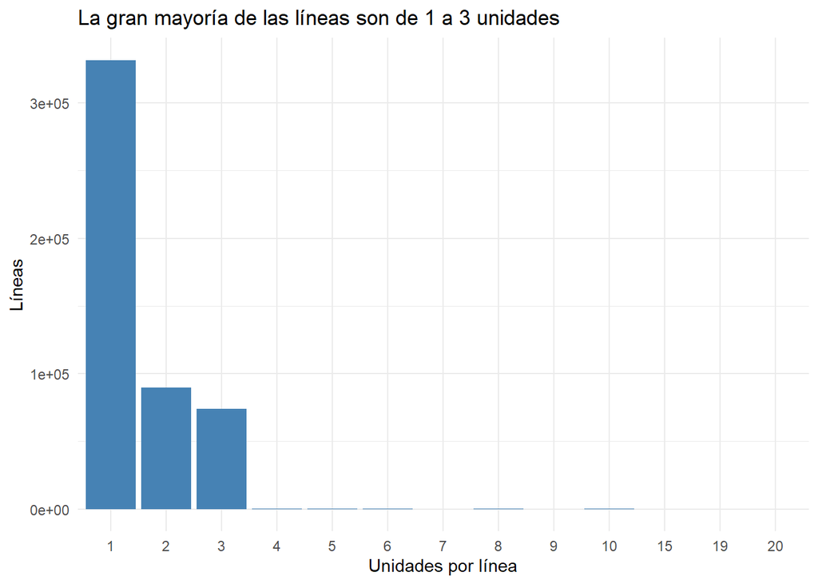

```r
datos %>% count(cantidad) %>%
  ggplot(aes(factor(cantidad), n)) + geom_col(fill = "steelblue") +
  labs(x = "Unidades por línea", y = "Líneas",
       title = "La gran mayoría de las líneas son de 1 a 3 unidades")
```

### 2.5.2 Compras por año

```
## # A tibble: 10 × 4
##     anio facturas compradores unidades
##    <int>    <int>       <int>    <dbl>
##  1  2013    10138        1739    32709
##  2  2014    20926        2060    61529
##  3  2015    22343        2261    60592
##  4  2016    25779        2490    73629
##  5  2017    30732        2855    88457
##  6  2018    31980        2703    90210
##  7  2019    34247        2872    92405
##  8  2020    30579        2787    96052
##  9  2021    35390        3033   114849
## 10  2022     8634        2459    27322
```

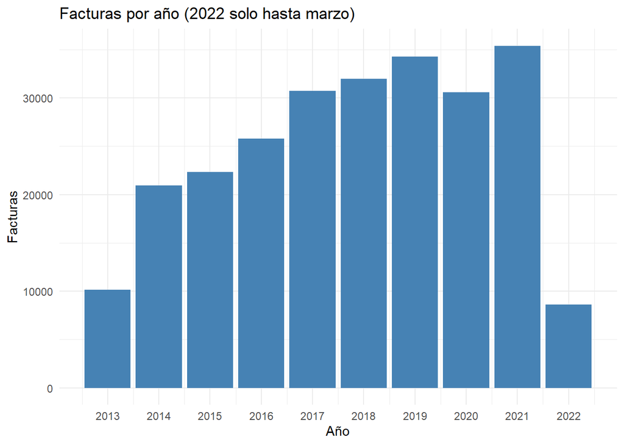

```r
datos %>%
  mutate(anio = as.integer(format(fecha, "%Y"))) %>%
  group_by(anio) %>%
  summarise(facturas = n_distinct(invoice),
            compradores = n_distinct(colaborador),
            unidades = sum(cantidad)) %>%
  print() %>%
  ggplot(aes(anio, facturas)) + geom_col(fill = "steelblue") +
  scale_x_continuous(breaks = 2013:2022) +
  labs(x = "Año", y = "Facturas", title = "Facturas por año (2022 solo hasta marzo)")
```

### 2.5.3 Comportamiento de los compradores

```r
por_comprador <- datos %>%
  group_by(colaborador) %>%
  summarise(facturas = n_distinct(invoice),
            productos_distintos = n_distinct(Material),
            unidades = sum(cantidad))

summary(por_comprador[, -1])
```

```
##     facturas      productos_distintos    unidades
##  Min.   :  1.00   Min.   :  1.00      Min.   :   1.0
##  1st Qu.:  4.00   1st Qu.:  6.00      1st Qu.:  11.0
##  Median : 19.00   Median : 22.00      Median :  51.0
##  Mean   : 42.59   Mean   : 36.76      Mean   : 125.3
##  3rd Qu.: 65.00   3rd Qu.: 57.00      3rd Qu.: 173.2
##  Max.   :453.00   Max.   :267.00      Max.   :2434.0
```

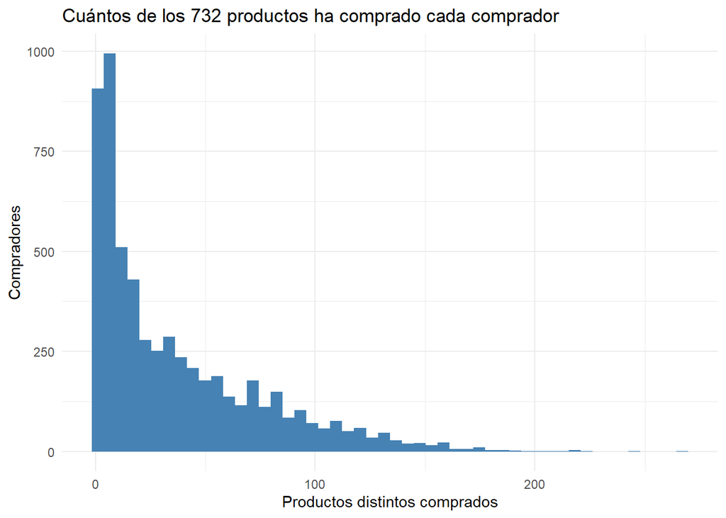

```r
ggplot(por_comprador, aes(productos_distintos)) +
  geom_histogram(bins = 50, fill = "steelblue") +
  labs(x = "Productos distintos comprados", y = "Compradores",
       title = "Cuántos de los 732 productos ha comprado cada comprador")
```

### 2.5.4 Concentración en pocos productos

```r
por_producto <- datos %>%
  group_by(Material, description) %>%
  summarise(unidades = sum(cantidad),
            compradores = n_distinct(colaborador), .groups = "drop") %>%
  arrange(desc(unidades)) %>%
  mutate(pct_acumulado = 100 * cumsum(unidades) / sum(unidades))

head(por_producto, 10)
```

```
## # A tibble: 10 × 5
##    Material  description                      unidades compradores pct_acumulado
##    <chr>     <chr>                               <dbl>       <int>         <dbl>
##  1 300000712 GINKGO BILOBA 40 mg CBG CJA x20…    63908        3071          8.66
##  2 300001554 NISTATINA+OXIDO DE ZINC UNGU TU…    34986        2174         13.4
##  3 500001475 TAPA BOCAS X 50UN                   14236        2200         15.3
##  4 300000869 VITAMINA E 400 UI FCO x 50 CBG …    14046        3083         17.2
##  5 300000714 VITAMINA E 1000 UI FCO x 30 CBG     13544        2606         19.1
##  6 300005439 NUTRIGEL 2.0 SABOR NRJA CJAx30S…    13540        2459         20.9
##  7 300004184 GESTAVIT DHA CBG CAJA x 30 UND …    12282        2345         22.6
##  8 300000848 VITAMINA E 400 CBG CJA x 100 UND     9792        2057         23.9
##  9 300001535 CLOTRIMAZOL CREMA TOPICA x 40 g…     9317        1667         25.2
## 10 300005440 NUTRIGEL 2.0 SABOR NTRO CJAx30S…     9090        2024         26.4
```

```r
# ¿Cuántos productos concentran el 50 % y el 80 % de las unidades?
c(productos_50pct = sum(por_producto$pct_acumulado <= 50) + 1,
  productos_80pct = sum(por_producto$pct_acumulado <= 80) + 1)
```

```
## productos_50pct productos_80pct
##              40             146
```

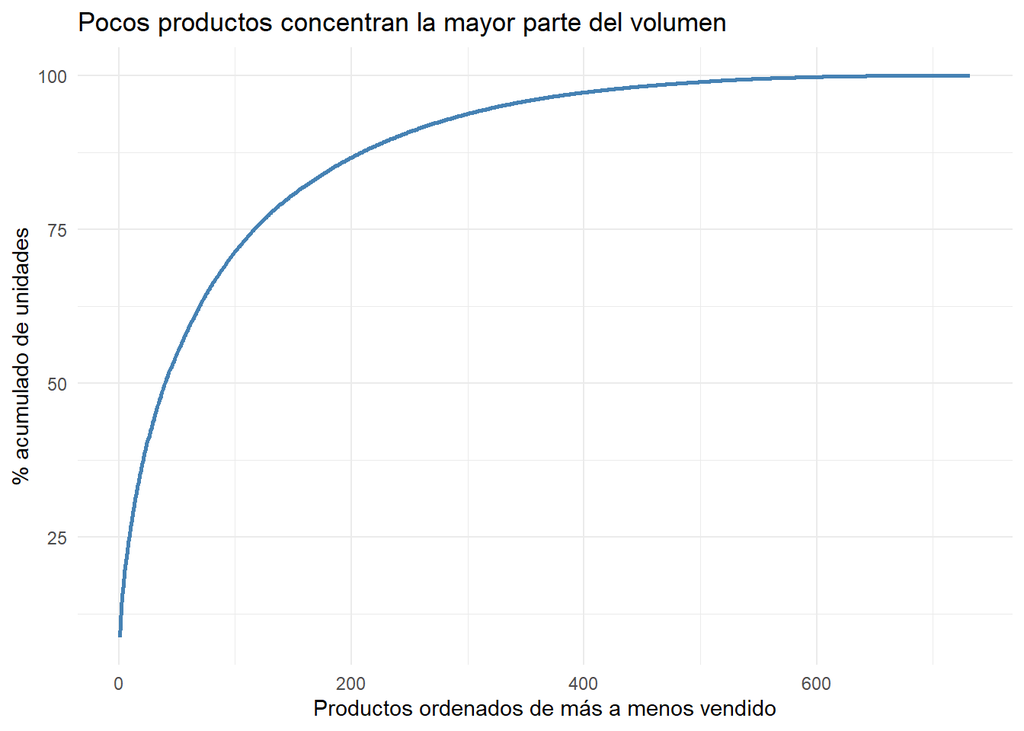

```r
ggplot(por_producto, aes(seq_along(pct_acumulado), pct_acumulado)) +
  geom_line(color = "steelblue", linewidth = 1) +
  labs(x = "Productos ordenados de más a menos vendido", y = "% acumulado de unidades",
       title = "Pocos productos concentran la mayor parte del volumen")
```

Esta concentración es la razón por la que la fase 7 compara contra la línea base de “los 10 más vendidos”: un recomendador ingenuo tenderá a sugerir siempre estos productos.

### 2.5.5 Otras variables

```r
datos %>% count(formula_medica) %>% mutate(pct = round(100 * n / sum(n), 2))
```

```
## # A tibble: 2 × 3
##   formula_medica      n   pct
##   <chr>           <int> <dbl>
## 1 NO             494756 99.7
## 2 SI               1619  0.33
```

```r
datos %>% count(IVA) %>% mutate(pct = round(100 * n / sum(n), 2))
```

```
## # A tibble: 3 × 3
##     IVA      n   pct
##   <dbl>  <int> <dbl>
## 1     0 363347 73.2
## 2    16  39548  7.97
## 3    19  93480 18.8
```

```r
cab %>% filter(invoice %in% datos$invoice) %>% count(`Creado desde`)
```

```
## # A tibble: 2 × 2
##   `Creado desde`      n
##   <chr>           <int>
## 1 SAP            241772
## 2 WEB              8976
```

```r
cab %>% filter(invoice %in% datos$invoice) %>% count(`Sociedad facturadora`)
```

```
## # A tibble: 2 × 2
##   `Sociedad facturadora`      n
##   <chr>                   <int>
## 1 DIABETRICS               6949
## 2 PROCAPS                243799
```

# 3 Fase 3 · Preferencia implícita y matriz usuario–producto

En los libros, la preferencia era explícita: una calificación de 1 a 10. En la farmacia solo sabemos **cuánto compró** cada comprador de cada producto. Esta fase compara cuatro formas de convertir esas compras en una “preferencia”, construye la matriz usuario–producto, calcula su dispersión y elige una definición **con datos**: además del análisis descriptivo, hacemos una validación rápida con partición temporal, probando también si conviene exigir un mínimo de compradores en común entre dos productos.

## 3.1 Datos de partida

Partimos de la tabla unida en la Fase 2 (`fase2_datos.Rmd` la guarda en `data/`).

```r
datos    <- readRDS("data/datos_unidos.rds")
catalogo <- readRDS("data/catalogo.rds")
c(lineas = nrow(datos), compradores = n_distinct(datos$colaborador),
  productos = n_distinct(datos$Material))
```

```
##      lineas compradores   productos
##      496375        5888         732
```

## 3.2 Cuatro definiciones de preferencia

Para cada par (comprador, producto) calculamos:

| Definición | Fórmula | Qué mide |
| --- | --- | --- |
| `suma` | $\sum$ `cantidad` | Volumen total comprado |
| `facturas` | número de facturas distintas | Cuántas veces volvió a comprarlo (recompra) |
| `binaria` | 1 si lo compró alguna vez | Solo si lo compró o no |
| `log` | $\log(1 + \sum$ `cantidad`$)$ | Volumen, pero comprimiendo la cola larga |

```r
pares <- datos %>%
  group_by(colaborador, Material) %>%
  summarise(suma     = sum(cantidad),
            facturas = n_distinct(invoice),
            .groups  = "drop") %>%
  mutate(binaria = 1,
         log     = log1p(suma))

nrow(pares)   # celdas no vacías de la matriz
```

```
## [1] 216414
```

```r
summary(pares[, c("suma", "facturas", "log")])
```

```
##       suma            facturas           log
##  Min.   :  1.000   Min.   : 1.000   Min.   :0.6931
##  1st Qu.:  1.000   1st Qu.: 1.000   1st Qu.:0.6931
##  Median :  2.000   Median : 1.000   Median :1.0986
##  Mean   :  3.409   Mean   : 2.284   Mean   :1.1873
##  3rd Qu.:  3.000   3rd Qu.: 2.000   3rd Qu.:1.3863
##  Max.   :263.000   Max.   :88.000   Max.   :5.5759
```

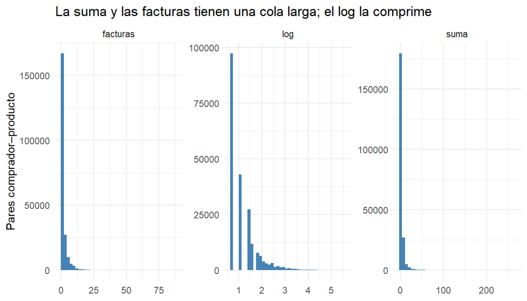

```r
pares %>%
  select(suma, facturas, log) %>%
  pivot_longer(everything(), names_to = "definicion", values_to = "valor") %>%
  ggplot(aes(valor)) +
  geom_histogram(bins = 40, fill = "steelblue") +
  facet_wrap(~ definicion, scales = "free") +
  labs(x = NULL, y = "Pares comprador–producto",
       title = "La suma y las facturas tienen una cola larga; el log la comprime")
```

La suma va de 1 a 263 y el número de facturas de 1 a 88, con la mayoría de los pares en valores muy bajos. Esa cola es el problema: en el coseno, cada valor entra **al cuadrado**, así que un par con suma 200 pesa 40.000 veces más que uno con suma 1.

## 3.3 Matriz usuario–producto y dispersión

```r
compradores <- sort(unique(pares$colaborador))
productos   <- sort(unique(pares$Material))

# construye la matriz densa comprador × producto para una columna de "pares";
# las celdas sin compra quedan en 0 (no compró), no en NA
hacer_matriz <- function(pares, columna, filas = compradores, cols = productos) {
  m <- matrix(0, nrow = length(filas), ncol = length(cols),
              dimnames = list(filas, cols))
  m[cbind(match(pares$colaborador, filas), match(pares$Material, cols))] <- pares[[columna]]
  m
}

definiciones <- c("suma", "facturas", "binaria", "log")
matrices <- lapply(setNames(definiciones, definiciones), function(d) hacer_matriz(pares, d))

dim(matrices$suma)
```

```
## [1] 5888  732
```

```r
matrices$suma[1:5, 1:6]
```

```
##           300000001 300000003 300000004 300000006 300000010 300000012
## 700000000         0         0         0         0         0         2
## 700000001         0         0         0         0         0         5
## 700000002         0         0         0         0         0         0
## 700000003         0         0         0         0         0         0
## 700000004         0         0         0         0         0         0
```

**Dispersión calculada correctamente.** Es la proporción de celdas vacías sobre el total de celdas de la matriz **completa** (5.888 × 732), sin recortar filas ni columnas como hacía el `top_n(10000)` del tutorial:

```r
celdas_total <- length(compradores) * length(productos)
c(celdas_total = celdas_total,
  celdas_con_compra = nrow(pares),
  dispersion = 1 - nrow(pares) / celdas_total)
```

```
##      celdas_total celdas_con_compra        dispersion
##      4.310016e+06      2.164140e+05      9.497881e-01
```

```r
# comprobación con la matriz: misma cifra contando ceros
mean(matrices$binaria == 0)
```

```
## [1] 0.9497881
```

Es decir, cerca del 95 % de la matriz está vacía, frente al 99,98 % de los libros. Ojo con la interpretación: **una celda vacía significa “no lo compró”, no “no le gusta”**. Puede que no lo necesite, que no lo conozca o que lo compre en otra parte.

Con 5.888 × 732 la matriz cabe sin problema en memoria como matriz densa (33.3 Mb), así que no hace falta una representación dispersa.

## 3.4 ¿Qué definición evita que un mayorista domine?

Para la similitud ítem–ítem, cada producto es un vector columna. En el coseno, la contribución de un comprador a la norma de ese vector es su valor al cuadrado. Medimos, para cada producto, **qué parte de la norma al cuadrado aporta su comprador más grande**: si es cercana a 1, la similitud de ese producto con los demás la decide prácticamente una sola persona.

```r
cuota_max <- function(m) {
  apply(m, 2, function(x) max(x^2) / sum(x^2))
}

dominancia <- sapply(matrices, cuota_max)

tibble(definicion = definiciones,
       mediana_cuota_comprador_top = apply(dominancia, 2, median),
       p90 = apply(dominancia, 2, quantile, 0.9),
       productos_dominados_50pct = colSums(dominancia > 0.5)) %>%
  mutate(across(where(is.numeric), ~ round(.x, 3)))
```

```
## # A tibble: 4 × 4
##   definicion mediana_cuota_comprador_top   p90 productos_dominados_50pct
##   <chr>                            <dbl> <dbl>                     <dbl>
## 1 suma                             0.16  0.507                        75
## 2 facturas                         0.125 0.482                        57
## 3 binaria                          0.009 0.124                        10
## 4 log                              0.046 0.268                        25
```

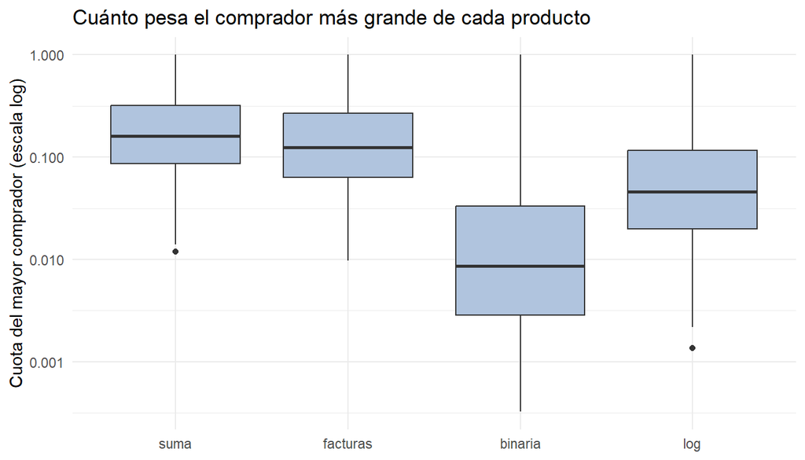

```r
as_tibble(dominancia) %>%
  pivot_longer(everything(), names_to = "definicion", values_to = "cuota") %>%
  mutate(definicion = factor(definicion, levels = definiciones)) %>%
  ggplot(aes(definicion, cuota)) +
  geom_boxplot(fill = "lightsteelblue") +
  scale_y_log10() +
  labs(x = NULL, y = "Cuota del mayor comprador (escala log)",
       title = "Cuánto pesa el comprador más grande de cada producto")
```

Un ejemplo concreto: el producto más vendido y lo que pesa su mayor comprador con cada definición.

```r
top_prod <- pares %>% group_by(Material) %>% summarise(u = sum(suma)) %>%
  slice_max(u, n = 1) %>% pull(Material)
catalogo %>% filter(Material == top_prod) %>% pull(description)
```

```
## [1] "GINKGO BILOBA 40 mg CBG CJA x20 UND CIAL"
```

```r
pares %>% filter(Material == top_prod) %>%
  slice_max(suma, n = 3) %>% select(colaborador, suma, facturas, log)
```

```
## # A tibble: 3 × 4
##   colaborador  suma facturas   log
##   <chr>       <dbl>    <int> <dbl>
## 1 700001564     263       88  5.58
## 2 700002689     225       76  5.42
## 3 700000465     215       72  5.38
```

```r
round(dominancia[top_prod, ], 4)
```

```
##     suma facturas  binaria      log
##   0.0198   0.0174   0.0003   0.0014
```

**Lectura:** la `suma` es la más expuesta a un comprador mayorista; el número de `facturas` lo es menos (repetir compras requiere tiempo, no solo volumen); `log` reduce mucho el peso de los grandes volúmenes, y la `binaria` lo elimina por completo, porque cada comprador cuenta igual. El costo de la binaria es que descarta la información de intensidad: comprar una vez pesa lo mismo que comprar cada mes.

## 3.5 Validación temporal rápida: ¿qué definición recomienda mejor?

El análisis anterior dice qué definición es **más robusta**, pero no cuál **recomienda mejor**. Para decidirlo con datos hacemos una versión rápida de la evaluación de la Fase 7 (que la hará completa, con intervalos de confianza y comparación con la línea base):

- **Entrenamiento:** compras hasta el 31/12/2020. **Prueba:** compras de 2021–2022.
- Para cada comprador presente en ambos periodos, se recomiendan 10 productos con el recomendador ítem–ítem: la puntuación de un producto es la suma de sus similitudes de coseno con los productos que el comprador ya tiene, ponderadas por su preferencia ($\text{puntuación} = X \cdot S$).
- Se **excluyen** los productos que ya compró en entrenamiento.
- Acierto: el producto recomendado aparece entre sus compras **nuevas** de 2021–2022.

También probamos un **mínimo de compradores en común**: la similitud entre dos productos se pone en 0 si menos de *m* compradores compraron los dos. Con *m* = 1 no hay filtro. La idea viene de la Fase 1, donde las similitudes de los libros descansaban en 2 o 3 usuarios.

```r
corte <- as.Date("2020-12-31")

pares_periodo <- function(d) {
  d %>% group_by(colaborador, Material) %>%
    summarise(suma = sum(cantidad), facturas = n_distinct(invoice), .groups = "drop") %>%
    mutate(binaria = 1, log = log1p(suma))
}
entrena <- pares_periodo(filter(datos, fecha <= corte))
prueba  <- pares_periodo(filter(datos, fecha >  corte))

usuarios_eval <- intersect(unique(entrena$colaborador), unique(prueba$colaborador))

# compras nuevas en prueba: productos que el comprador no tenía en entrenamiento
nuevas <- prueba %>%
  filter(colaborador %in% usuarios_eval) %>%
  anti_join(entrena, by = c("colaborador", "Material")) %>%
  select(colaborador, Material)

usuarios_eval <- intersect(usuarios_eval, unique(nuevas$colaborador))  # con algo nuevo que acertar

c(compradores_en_ambos_periodos_con_compras_nuevas = length(usuarios_eval),
  compras_nuevas = nrow(nuevas))
```

```
## compradores_en_ambos_periodos_con_compras_nuevas
##                                             2533
##                                   compras_nuevas
##                                            27901
```

```r
compr_tr <- sort(unique(entrena$colaborador))

cos_matriz <- function(X) {                    # coseno entre todas las columnas
  normas <- sqrt(colSums(X^2))
  S <- crossprod(X) / outer(normas, normas)
  S[is.nan(S)] <- 0
  diag(S) <- 0                                 # un producto no se recomienda a sí mismo
  S
}

B_tr <- hacer_matriz(entrena, "binaria", filas = compr_tr)
comunes <- crossprod(B_tr)                     # compradores en común entre cada par de productos

# matriz de aciertos: comprador × producto (1 si es compra nueva en prueba)
verdad <- matrix(0, length(usuarios_eval), length(productos),
                 dimnames = list(usuarios_eval, productos))
verdad[cbind(match(nuevas$colaborador, usuarios_eval), match(nuevas$Material, productos))] <- 1

evaluar <- function(definicion, m, n = 10) {
  X <- hacer_matriz(entrena, definicion, filas = compr_tr)
  S <- cos_matriz(X)
  S[comunes < m] <- 0                          # umbral de compradores en común
  Xu <- X[usuarios_eval, ]
  puntaje <- Xu %*% S
  puntaje[Xu > 0] <- -Inf                      # excluye lo ya comprado
  top <- t(apply(puntaje, 1, function(p) order(p, decreasing = TRUE)[1:n]))
  aciertos <- matrix(verdad[cbind(rep(seq_along(usuarios_eval), n), as.vector(top))],
                     ncol = n)
  tibble(definicion = definicion, min_comunes = m,
         hit_rate_10   = mean(rowSums(aciertos) > 0),
         precision_10  = mean(rowSums(aciertos) / n))
}
```

**Verificación de la exclusión:** ningún producto recomendado debe estar entre los que el comprador ya tenía en entrenamiento.

```r
X <- hacer_matriz(entrena, "binaria", filas = compr_tr)[usuarios_eval, ]
p <- X %*% cos_matriz(hacer_matriz(entrena, "binaria", filas = compr_tr))
p[X > 0] <- -Inf
top <- t(apply(p, 1, function(z) order(z, decreasing = TRUE)[1:10]))
sum(X[cbind(rep(seq_len(nrow(X)), 10), as.vector(top))] > 0)   # debe ser 0
```

```
## [1] 0
```

```r
umbrales <- c(1, 2, 3, 5, 10, 20, 50)
resultados <- bind_rows(lapply(definiciones, function(d)
  bind_rows(lapply(umbrales, function(m) evaluar(d, m)))))

resultados %>%
  mutate(across(c(hit_rate_10, precision_10), ~ round(100 * .x, 2))) %>%
  pivot_wider(id_cols = min_comunes, names_from = definicion,
              values_from = hit_rate_10) %>%
  rename(`mínimo de compradores en común` = min_comunes)
```

```
## # A tibble: 7 × 5
##   `mínimo de compradores en común`  suma facturas binaria   log
##                              <dbl> <dbl>    <dbl>   <dbl> <dbl>
## 1                                1  66.0     65.8    65.4  66.1
## 2                                2  66.0     65.8    65.4  66.1
## 3                                3  66.0     65.8    65.4  66.1
## 4                                5  66.1     65.8    65.3  66.2
## 5                               10  66.2     65.9    65.3  66.2
## 6                               20  66.1     65.6    65.3  66.2
## 7                               50  66.0     65.4    65.5  65.9
```

La tabla muestra el **hit rate@10 (%)**: el porcentaje de compradores para los que al menos una de las 10 recomendaciones fue una compra nueva en 2021–2022.

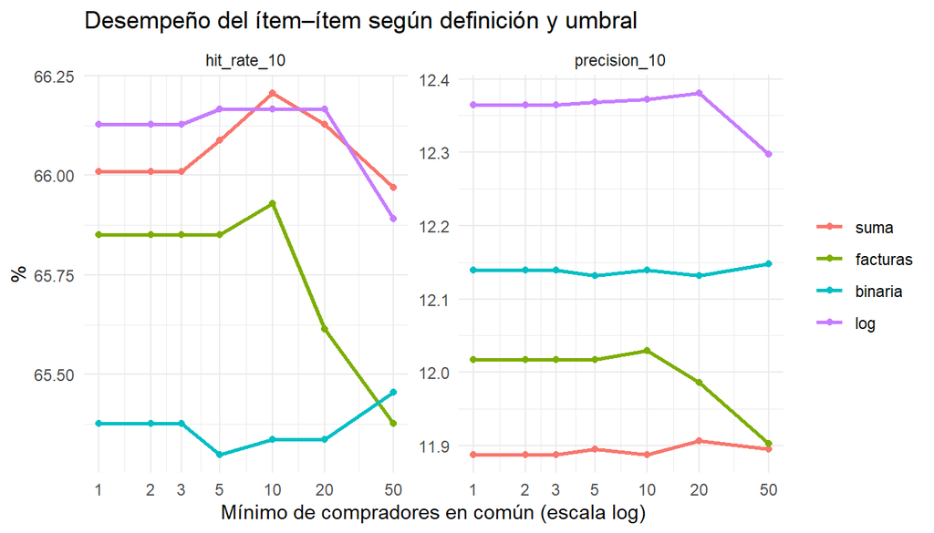

```r
resultados %>%
  pivot_longer(c(hit_rate_10, precision_10), names_to = "metrica", values_to = "valor") %>%
  mutate(definicion = factor(definicion, levels = definiciones)) %>%
  ggplot(aes(min_comunes, 100 * valor, color = definicion)) +
  geom_line(linewidth = 1) + geom_point() +
  scale_x_log10(breaks = umbrales) +
  facet_wrap(~ metrica, scales = "free_y") +
  labs(x = "Mínimo de compradores en común (escala log)", y = "%", color = NULL,
       title = "Desempeño del ítem–ítem según definición y umbral")
```

Las diferencias son de décimas de punto. Para saber si alguna es real, calculamos el intervalo de confianza del 95 % del hit rate@10 (proporción de 2533 compradores, aproximación normal):

```r
n_eval <- length(usuarios_eval)
sin_umbral <- resultados %>%
  filter(min_comunes == 1) %>%
  mutate(ee = sqrt(hit_rate_10 * (1 - hit_rate_10) / n_eval),
         ic_inf = hit_rate_10 - 1.96 * ee,
         ic_sup = hit_rate_10 + 1.96 * ee) %>%
  arrange(desc(hit_rate_10))

sin_umbral %>%
  transmute(definicion,
            `hit rate@10 (%)` = round(100 * hit_rate_10, 1),
            `IC 95 % (%)` = paste0("[", round(100 * ic_inf, 1), ", ", round(100 * ic_sup, 1), "]"),
            `precision@10 (%)` = round(100 * precision_10, 1))
```

```
## # A tibble: 4 × 4
##   definicion `hit rate@10 (%)` `IC 95 % (%)` `precision@10 (%)`
##   <chr>                  <dbl> <chr>                      <dbl>
## 1 log                     66.1 [64.3, 68]                  12.4
## 2 suma                    66   [64.2, 67.9]                11.9
## 3 facturas                65.9 [64, 67.7]                  12
## 4 binaria                 65.4 [63.5, 67.2]                12.1
```

Todos los intervalos se traslapan ampliamente: **con estos datos, las cuatro definiciones recomiendan igual de bien**. La diferencia entre la mejor y la peor (0.8 puntos) es menor que el error estándar de cada una (0.9 puntos).

**¿Por qué el umbral de compradores en común no cambia nada?** Veamos cuántos pares de productos elimina cada umbral y cuántos compradores en común tienen los vecinos que de verdad usa el recomendador (los 10 más similares de cada producto):

```r
S_log <- cos_matriz(hacer_matriz(entrena, "log", filas = compr_tr))
con_similitud <- S_log > 0

tibble(min_comunes = umbrales,
       pares_con_similitud = sum(con_similitud) / 2,
       pares_eliminados = sapply(umbrales, function(m) sum(con_similitud & comunes < m) / 2),
       pct_eliminados = round(100 * pares_eliminados / pares_con_similitud, 1))
```

```
## # A tibble: 7 × 4
##   min_comunes pares_con_similitud pares_eliminados pct_eliminados
##         <dbl>               <dbl>            <dbl>          <dbl>
## 1           1              175046                0            0
## 2           2              175046            25088           14.3
## 3           3              175046            40763           23.3
## 4           5              175046            61490           35.1
## 5          10              175046            89419           51.1
## 6          20              175046           115443           66
## 7          50              175046           144159           82.4
```

```r
# compradores en común entre cada producto y sus 10 vecinos más similares
comunes_top10 <- sapply(seq_len(ncol(S_log)), function(j) {
  vecinos <- order(S_log[, j], decreasing = TRUE)[1:10]
  comunes[vecinos, j]
})
summary(as.vector(comunes_top10))
```

```
##    Min. 1st Qu.  Median    Mean 3rd Qu.    Max.
##     0.0     2.0    41.0   152.2   175.0  2085.0
```

```r
mean(comunes_top10 < 5)   # proporción de vecinos top-10 con menos de 5 compradores en común
```

```
## [1] 0.3084699
```

¿Los vecinos con poco respaldo son de productos poco vendidos? Comparamos el número de compradores de los productos según cuántos de sus 10 vecinos tienen menos de 5 compradores en común:

```r
compradores_producto <- colSums(B_tr)
tibble(vecinos_debiles = colSums(comunes_top10 < 5),
       compradores = compradores_producto) %>%
  mutate(grupo = cut(vecinos_debiles, c(-1, 0, 5, 10),
                     labels = c("ninguno", "1 a 5", "6 a 10"))) %>%
  group_by(`vecinos top-10 con < 5 compradores en común` = grupo) %>%
  summarise(productos = n(), mediana_compradores = median(compradores))
```

```
## # A tibble: 3 × 3
##   `vecinos top-10 con < 5 compradores en común` productos mediana_compradores
##   <fct>                                             <int>               <dbl>
## 1 ninguno                                             393               265
## 2 1 a 5                                               127                46
## 3 6 a 10                                              212                 4.5
```

**Lectura.** Los pares con poco respaldo **sí** llegan al top 10 de muchos productos (en 31 % de los casos), pero casi siempre en productos que compran muy pocas personas: con tan pocos compradores, cualquier coincidencia da un coseno alto, el mismo fenómeno que vimos con los libros. Aun así, el umbral no cambia el hit rate, porque esos productos raros casi no aparecen en el historial de los compradores evaluados, y la puntuación de un comprador suma similitudes sobre todo su historial (22 productos en la mediana), lo que diluye cualquier par aislado.

## 3.6 Decisión

**Definición elegida: `log` = log(1 + suma de cantidad).** Como las cuatro definiciones recomiendan igual de bien, el desempeño no decide y decide la **robustez**:

- La `suma` y las `facturas` son las más expuestas a un comprador grande: en 75 productos un solo comprador aporta más de la mitad de la norma con la suma.
- `log` reduce eso a 25 productos y **conserva** la información de intensidad (comprar 50 unidades sigue pesando más que comprar 1, pero no 50 veces más).
- La `binaria` es la más robusta (10 productos), pero descarta la intensidad por completo. `log` tiene además la precisión@10 más alta, aunque la diferencia tampoco es significativa.

**Sesgos que hay que reconocer en el informe:**

1. **No comprar no es rechazo.** Las celdas en 0 mezclan “no le interesa” con “no lo conoce”.
2. **Sesgo de popularidad.** Los productos muy vendidos (Ginkgo, Nistatina) coinciden con casi todos, y la similitud tiende a sugerirlos siempre. La Fase 7 lo controla con la línea base.
3. **Antigüedad del comprador.** Quien lleva más años acumula más productos y más volumen; las definiciones de volumen premian la antigüedad, no la preferencia.
4. **Presentaciones del mismo producto.** Un mismo medicamento en dos presentaciones son dos códigos distintos, y saldrán muy similares entre sí. Eso es correcto, pero poco útil como recomendación; lo revisaremos en la Fase 5.

Esta validación es una guía para elegir; la evaluación formal, con la comparación contra los 10 más vendidos, es la Fase 7.

```r
definicion_elegida <- "log"
umbral_elegido     <- 5
user_item          <- matrices[[definicion_elegida]]
saveRDS(list(user_item = user_item, definicion = definicion_elegida,
             umbral = umbral_elegido, pares = pares),
        "data/matriz_usuario_producto.rds")
```

# 4 Fase 4 · Similitud de coseno

## 4.1 Datos de partida

Usamos la matriz usuario–producto de la Fase 3: 5.888 compradores × 732 productos, con la preferencia **log(1 + cantidad)** y 0 donde no hubo compra.

```r
fase3    <- readRDS("data/matriz_usuario_producto.rds")
X        <- fase3$user_item
catalogo <- readRDS("data/catalogo.rds")
nombre   <- function(codigo) catalogo$description[match(codigo, catalogo$Material)]

c(definicion = fase3$definicion, umbral_comunes = fase3$umbral)
```

```
##     definicion umbral_comunes
##          "log"            "5"
```

```r
dim(X)
```

```
## [1] 5888  732
```

## 4.2 La similitud de coseno

Para dos vectores $A$ y $B$ (dos columnas de la matriz, es decir, dos productos):

$$\cos(A, B) = \frac{A \cdot B}{\lVert A
\rVert \, \lVert B \rVert}
= \frac{\sum_i A_i B_i}{\sqrt{\sum_i A_i^2}\,\sqrt{\sum_i
B_i^2}}$$

- El **numerador** solo suma sobre los compradores que compraron **los dos** productos (si uno de los dos es 0, el producto $A_i B_i$ es 0).
- El **denominador** divide por el “tamaño” de cada vector, así que el coseno no depende de cuánto se vende un producto, sino de **quiénes** lo compran y en qué proporción.
- Como todas las preferencias son $\geq 0$, el coseno queda entre **0** (ningún comprador en común) y **1** (los mismos compradores, en la misma proporción).

### 4.2.1 ¿Qué significa geométricamente un coseno de 0,8?

Cada producto es una flecha en un espacio de 5.888 dimensiones, una por comprador. El coseno es el coseno del **ángulo** entre las dos flechas:

```r
tibble(coseno = c(1, 0.9, 0.8, 0.5, 0.2, 0)) %>%
  mutate(angulo_grados = round(acos(coseno) * 180 / pi, 1))
```

```
## # A tibble: 6 × 2
##   coseno angulo_grados
##    <dbl>         <dbl>
## 1    1             0
## 2    0.9          25.8
## 3    0.8          36.9
## 4    0.5          60
## 5    0.2          78.5
## 6    0            90
```

Un coseno de 0,8 corresponde a un ángulo de unos **37°**: las dos flechas apuntan en una dirección parecida. En términos de negocio: los dos productos los compran en buena parte los **mismos compradores**, y en proporciones parecidas. No dice nada de la cantidad total vendida: un producto que vende 10 veces más que otro puede tener coseno 1 con él si se reparte entre los compradores de la misma forma.

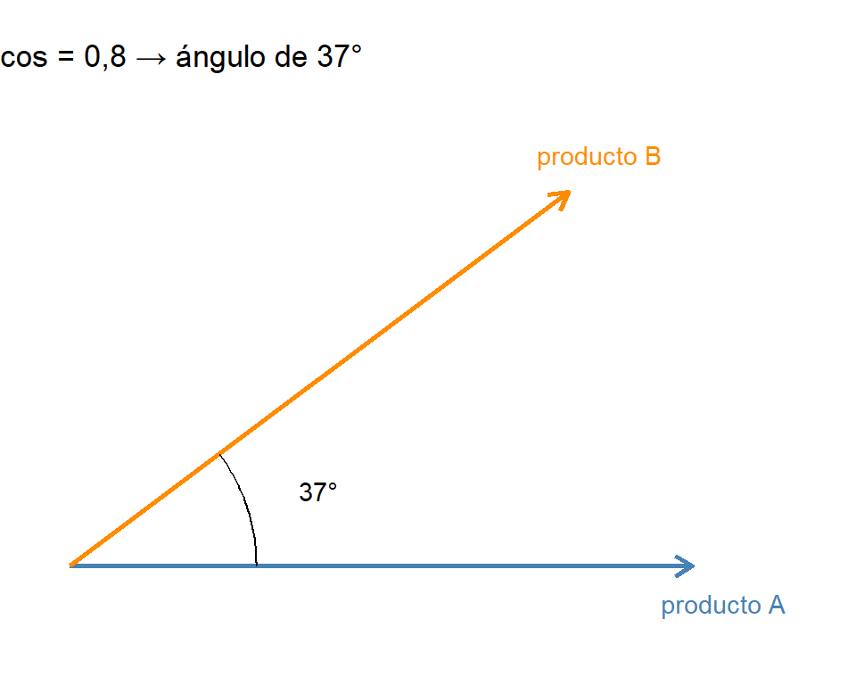

## 4.3 Nuestra función

Partimos de la función del tutorial y la ajustamos a la farmacia:

```r
cos_similarity <- function(A, B) {
  num <- sum(A * B)                         # producto punto: solo cuentan compradores comunes
  den <- sqrt(sum(A^2)) * sqrt(sum(B^2))    # producto de las normas
  if (den == 0) return(NaN)                 # un vector de ceros no tiene dirección: 0/0
  num / den
}
```

**Cambios respecto al tutorial:**

- Se quitó `na.rm = TRUE`: en nuestra matriz “no compró” es 0, no `NA`, así que no hay valores faltantes que ignorar. Si apareciera un `NA` sería un error de construcción y preferimos que se note.
- El caso de un vector de ceros (un producto sin compradores) devuelve `NaN` de forma explícita, igual que `lsa::cosine`. En la matriz completa no ocurre (todos los productos tienen al menos un comprador), pero sí puede ocurrir en la partición de entrenamiento de la Fase 7, con productos lanzados después de 2020.

## 4.4 Validación contra `lsa::cosine`

Comparamos nuestra función con `lsa::cosine` en cinco pares elegidos para cubrir casos distintos:

```r
pares <- tribble(
  ~caso,                                    ~A,          ~B,
  "Los dos productos más vendidos",          "300000712", "300000869",
  "Dos presentaciones de vitamina E",        "300000869", "300000848",
  "Clotrimazol tópico vs. vaginal",          "300001535", "300001536",
  "Antimicótico vs. suplemento",             "300000700", "300004184",
  "Producto popular vs. uno poco vendido",   "300000712", names(which.min(colSums(X > 0)))
)

validacion <- pares %>%
  rowwise() %>%
  mutate(producto_A   = nombre(A),
         producto_B   = nombre(B),
         nuestra      = cos_similarity(X[, A], X[, B]),
         lsa          = as.numeric(lsa::cosine(X[, A], X[, B])),
         diferencia   = abs(nuestra - lsa),
         comunes      = sum(X[, A] > 0 & X[, B] > 0)) %>%
  ungroup()

validacion %>% select(caso, producto_A, producto_B, comunes, nuestra, lsa, diferencia)
```

```
## # A tibble: 5 × 7
##   caso                   producto_A producto_B comunes nuestra    lsa diferencia
##   <chr>                  <chr>      <chr>        <int>   <dbl>  <dbl>      <dbl>
## 1 Los dos productos más… GINKGO BI… VITAMINA …    2293  0.780  0.780    6.66e-16
## 2 Dos presentaciones de… VITAMINA … VITAMINA …    1630  0.677  0.677    4.33e-15
## 3 Clotrimazol tópico vs… CLOTRIMAZ… CLOTRIMAZ…     757  0.604  0.604    5.88e-15
## 4 Antimicótico vs. supl… FLUCONAZO… GESTAVIT …     533  0.387  0.387    6.66e-16
## 5 Producto popular vs. … GINKGO BI… EDUXON 75…       1  0.0283 0.0283   6.94e-18
```

```r
stopifnot(all(validacion$diferencia < 1e-12))   # el documento se detiene si no coinciden
```

Las dos funciones coinciden hasta la precisión numérica del computador (diferencias del orden de $10^{-16}$).

Validamos también un par de **compradores** (filas), que es lo que usará el recomendador usuario–usuario de la Fase 6:

```r
u <- rownames(X)[order(rowSums(X > 0), decreasing = TRUE)[1:2]]   # los dos compradores más diversos
c(nuestra = cos_similarity(X[u[1], ], X[u[2], ]),
  lsa     = as.numeric(lsa::cosine(X[u[1], ], X[u[2], ])))
```

```
##  nuestra      lsa
## 0.593882 0.593882
```

## 4.5 Matriz producto–producto completa

La matriz de 732 × 732 tiene unas 536.000 celdas, así que se puede precalcular una vez y consultar después. Calcularla con un doble ciclo llamaría a la función 267.546 veces. Con álgebra matricial es una sola operación: `crossprod(X)` da todos los productos punto $A \cdot B$ a la vez, y se divide por el producto de las normas.

```r
cos_matriz <- function(X) {
  normas <- sqrt(colSums(X^2))                  # norma de cada producto
  crossprod(X) / outer(normas, normas)          # t(X) %*% X dividido por ||A|| ||B||
}

tiempo_nuestra <- system.time(S <- cos_matriz(X))
dim(S)
```

```
## [1] 732 732
```

**Validación de la matriz completa** contra `lsa::cosine(X)`, que calcula la misma matriz con un doble ciclo:

```r
tiempo_lsa <- system.time(S_lsa <- lsa::cosine(X))

c(diferencia_maxima = max(abs(S - S_lsa)),
  segundos_nuestra  = unname(tiempo_nuestra["elapsed"]),
  segundos_lsa      = unname(tiempo_lsa["elapsed"]))
```

```
## diferencia_maxima  segundos_nuestra      segundos_lsa
##      2.398082e-14      1.860000e+00      6.413000e+01
```

```r
stopifnot(max(abs(S - S_lsa)) < 1e-12)
```

Y contra nuestra propia función de pares, en 200 pares al azar:

```r
set.seed(2026)
i <- sample(ncol(X), 200, replace = TRUE)
j <- sample(ncol(X), 200, replace = TRUE)
max(abs(mapply(function(a, b) cos_similarity(X[, a], X[, b]), i, j) - S[cbind(i, j)]))
```

```
## [1] 6.661338e-16
```

Propiedades que debe cumplir la matriz:

```r
c(simetrica        = isSymmetric(unname(S)),
  diagonal_es_1    = all(abs(diag(S) - 1) < 1e-12),
  entre_0_y_1      = all(S >= 0 & S <= 1 + 1e-12),
  sin_NaN          = !anyNA(S))
```

```
##     simetrica diagonal_es_1   entre_0_y_1       sin_NaN
##          TRUE          TRUE          TRUE          TRUE
```

## 4.6 Umbral de compradores en común

Siguiendo la decisión de la Fase 3, la similitud entre dos productos se pone en 0 si menos de 5 compradores compraron ambos.

```r
B       <- (X > 0) * 1
comunes <- crossprod(B)                         # compradores en común por par de productos

S_final <- S
S_final[comunes < fase3$umbral] <- 0
diag(S_final) <- 0                              # un producto no se recomienda a sí mismo

c(pares_con_similitud_antes   = (sum(S > 0) - ncol(S)) / 2,
  pares_con_similitud_despues = sum(S_final > 0) / 2)
```

```
##   pares_con_similitud_antes pares_con_similitud_despues
##                      210322                      138370
```

## 4.7 ¿Cómo se distribuyen las similitudes?

```r
valores <- S_final[upper.tri(S_final)]
summary(valores[valores > 0])
```

```
##    Min. 1st Qu.  Median    Mean 3rd Qu.    Max.
## 0.01088 0.06286 0.09435 0.11776 0.14701 0.85499
```

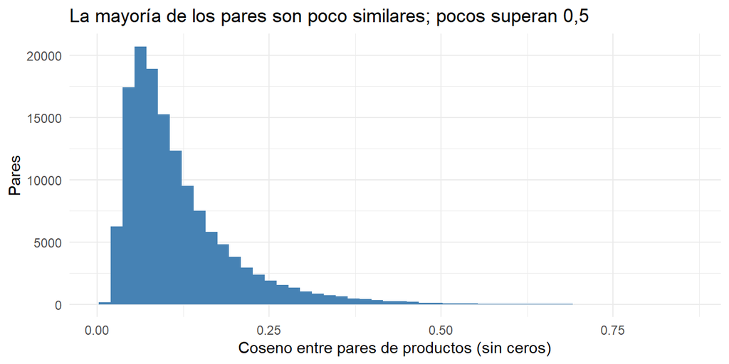

```r
tibble(similitud = valores[valores > 0]) %>%
  ggplot(aes(similitud)) + geom_histogram(bins = 50, fill = "steelblue") +
  labs(x = "Coseno entre pares de productos (sin ceros)", y = "Pares",
       title = "La mayoría de los pares son poco similares; pocos superan 0,5")
```

```r
c(pares_sobre_0.5 = sum(valores > 0.5), pares_sobre_0.8 = sum(valores > 0.8))
```

```
## pares_sobre_0.5 pares_sobre_0.8
##             455               1
```

### 4.7.1 Los pares más similares

```r
idx <- which(upper.tri(S_final), arr.ind = TRUE)
tibble(A = colnames(S_final)[idx[, 1]], B = colnames(S_final)[idx[, 2]],
       coseno = S_final[idx], comunes = comunes[idx]) %>%
  slice_max(coseno, n = 12) %>%
  mutate(producto_A = nombre(A), producto_B = nombre(B), coseno = round(coseno, 3)) %>%
  select(producto_A, producto_B, coseno, comunes)
```

```
## # A tibble: 12 × 4
##    producto_A                               producto_B            coseno comunes
##    <chr>                                    <chr>                  <dbl>   <dbl>
##  1 GLUCOQUICK DUAL (MEDIDOR GLUCO+COLESTER) TIRAS GLUCOQUICK COL…  0.855      46
##  2 GINKGO BILOBA 40 mg CBG CJA x20 UND CIAL VITAMINA E 400 UI FC…  0.78     2293
##  3 GINKGO BILOBA 40 mg CBG CJA x20 UND CIAL VITAMINA E 1000 UI F…  0.755    2061
##  4 NUTRIGEL 2.0 SABOR NRJA CJAx30SOBRE CIAL NUTRIGEL 2.0 SABOR N…  0.751    1587
##  5 VITAMINA E 400 UI FCO x 30 CBG (1+1)     VITAMINA E 400 UI FC…  0.739    1512
##  6 LANCETAS REGULARES CJA x 50 UND          TIRAS GLUCOQUICK 1 x…  0.719     517
##  7 TAPA BOCAS X 50UN                        PROTEKTA CAJA DISPEN…  0.716     866
##  8 VITAMINA E 1000 UI FCO x 30 CBG          VITAMINA E 400 UI FC…  0.716    1964
##  9 GINKGO BILOBA 40 mg CBG CJA x20 UND CIAL NISTATINA+OXIDO DE Z…  0.716    1828
## 10 KLEAR KIDS TOS JBE FCO x 120ml           DOLOFEN JBE FCO x 60…  0.712     968
## 11 GINKGO BILOBA 40 mg CBG CJA x20 UND CIAL VITAMINA E 400 CBG C…  0.704    1701
## 12 NOVAMIL PREMIUM 2 LATA X 400g CIAL       NOVAMIL PREMIUM 2 LA…  0.702     339
```

En los pares más similares aparecen tres patrones distintos, que serán el centro del análisis de la Fase 5:

1. **Complementos de un mismo tratamiento:** el medidor GlucoQuick con sus tiras, las lancetas con las tiras, el tapabocas con el dispensador. Son buenas recomendaciones: quien compra uno necesita el otro.
2. **Variantes del mismo producto:** Nutrigel en dos sabores, vitamina E en dos presentaciones, Novamil en dos tamaños. Tienen sentido, pero aportan poco como descubrimiento.
3. **Popularidad:** el Ginkgo Biloba aparece con coseno alto junto a la vitamina E, la nistatina, etc. No es que sean parte de un mismo tratamiento: son los productos que compran casi todos los compradores. Es el sesgo de popularidad que la Fase 7 medirá contra la línea base.

```r
saveRDS(list(S = S, S_final = S_final, comunes = comunes), "data/similitud_productos.rds")
```

# 5 Fase 5 · Recomendador ítem–ítem

## 5.1 Datos de partida

```r
fase3    <- readRDS("data/matriz_usuario_producto.rds")   # Fase 3: matriz log(1 + cantidad)
fase4    <- readRDS("data/similitud_productos.rds")       # Fase 4: coseno 732 × 732
catalogo <- readRDS("data/catalogo.rds")                  # Fase 2: un nombre por código

X        <- fase3$user_item
S        <- fase4$S_final      # coseno con umbral de 5 compradores en común y diagonal en 0
comunes  <- fase4$comunes
compradores_producto <- colSums(X > 0)

nombre <- function(codigo) catalogo$description[match(codigo, catalogo$Material)]
```

## 5.2 Buscar un producto por nombre

El prototipo debe permitir buscar por nombre, no por código. Esta función normaliza el texto (mayúsculas, sin tildes) y devuelve los productos cuyo nombre contiene todas las palabras buscadas, ordenados por número de compradores.

```r
normalizar <- function(x) toupper(iconv(x, to = "ASCII//TRANSLIT"))

buscar_producto <- function(texto) {
  palabras <- strsplit(normalizar(texto), "\\s+")[[1]]
  coincide <- Reduce(`&`, lapply(palabras, function(p)
    grepl(p, normalizar(catalogo$description), fixed = TRUE)))
  catalogo[coincide, ] %>%
    mutate(compradores = compradores_producto[Material]) %>%
    arrange(desc(compradores)) %>%
    select(Material, description, compradores)
}

buscar_producto("clotrimazol vaginal")
```

```
## # A tibble: 3 × 3
##   Material  description                              compradores
##   <chr>     <chr>                                          <dbl>
## 1 300001536 CLOTRIMAZOL CREMA VAGINAL x 40 g COLMED         1052
## 2 300007827 CLOTRIMAZOL 2%CREMA VAGINAL TUBOX20g CIA         740
## 3 300001537 CLOTRIMAZOL 1% CREMA VAGINAL TUBO x 40 g         228
```

## 5.3 La función `item_recommendation()`

Dado un producto (código `Material` o texto de búsqueda), devuelve los `n` productos más similares con su descripción.

```r
item_recommendation <- function(producto, n = 10, penalizacion = 0.25,
                                sim = S, n_comunes = comunes) {

  # acepta el código o un texto: si no es un código, toma el resultado más comprado
  if (!producto %in% colnames(sim)) {
    encontrados <- buscar_producto(producto)
    if (nrow(encontrados) == 0) stop("No se encontró ningún producto con: ", producto)
    producto <- encontrados$Material[1]
  }

  similitud <- sim[, producto]                    # coseno con todos los productos
  # puntaje para ordenar: el coseno, penalizado por la popularidad del candidato
  puntaje   <- similitud / compradores_producto[names(similitud)]^penalizacion

  tibble(Material    = names(similitud),
         description = nombre(Material),
         similitud   = similitud,
         compradores_en_comun = n_comunes[Material, producto],
         puntaje     = puntaje) %>%
    filter(Material != producto, similitud > 0) %>%   # ni el propio producto ni pares sin respaldo
    slice_max(puntaje, n = n, with_ties = FALSE) %>%
    mutate(producto_base = nombre(producto), .before = 1)
}
```

**Detalles de la función:**

- Usa la matriz de similitud **precalculada** en la Fase 4: no recalcula nada al consultar, así que la respuesta es inmediata (importante para el prototipo).
- La matriz ya trae el umbral de 5 compradores en común: los pares con menos respaldo tienen similitud 0 y se descartan con `similitud > 0`.
- `similitud` es siempre el coseno, que es lo que se reporta. `puntaje` solo se usa para **ordenar**. Con `penalizacion = 0`, ordenar por puntaje es ordenar por coseno, igual que en el tutorial. El parámetro se explica en la sección siguiente.

## 5.4 El problema de la popularidad

En la Fase 4 vimos que el Ginkgo Biloba y la vitamina E aparecen como similares a casi todo. Con el coseno puro (`penalizacion = 0`), las recomendaciones de un antimicótico vaginal son:

```r
item_recommendation("300001536", n = 8, penalizacion = 0) %>%
  select(description, similitud, compradores_en_comun)
```

```
## # A tibble: 8 × 3
##   description                              similitud compradores_en_comun
##   <chr>                                        <dbl>                <dbl>
## 1 CLOTRIMAZOL CREMA TOPICA x 40 g COLMED       0.604                  757
## 2 GINKGO BILOBA 40 mg CBG CJA x20 UND CIAL     0.558                  932
## 3 CLOTRIMAZOL 2%CREMA VAGINAL TUBOX20g CIA     0.553                  409
## 4 NISTATINA+OXIDO DE ZINC UNGU TUBOx60 g       0.515                  793
## 5 VITAMINA E 400 UI FCO x 50 CBG (1+1)         0.503                  886
## 6 VITAMINA E 1000 UI FCO x 30 CBG              0.501                  824
## 7 KLEAR KIDS TOS JBE FCO x 120ml               0.491                  603
## 8 VITAMINA E 400 UI FCO x 30 CBG (1+1)         0.487                  672
```

Salvo las otras presentaciones de clotrimazol, la lista es Ginkgo, nistatina, vitamina E y jarabe para la tos: productos que compran casi todos los compradores, sin relación terapéutica con una crema vaginal. ¿Pasa en general? Contamos, para los 732 productos, qué parte de sus 5 primeras recomendaciones son alguno de los 10 más vendidos:

```r
top10 <- names(sort(colSums(expm1(X)), decreasing = TRUE))[1:10]   # 10 más vendidos en unidades
nombre(top10)
```

```
##  [1] "GINKGO BILOBA 40 mg CBG CJA x20 UND CIAL"
##  [2] "NISTATINA+OXIDO DE ZINC UNGU TUBOx60 g"
##  [3] "TAPA BOCAS X 50UN"
##  [4] "VITAMINA E 400 UI FCO x 50 CBG (1+1)"
##  [5] "VITAMINA E 1000 UI FCO x 30 CBG"
##  [6] "NUTRIGEL 2.0 SABOR NRJA CJAx30SOBRE CIAL"
##  [7] "GESTAVIT DHA CBG CAJA x 30 UND CIAL"
##  [8] "VITAMINA E 400 CBG CJA x 100 UND"
##  [9] "CLOTRIMAZOL CREMA TOPICA x 40 g COLMED"
## [10] "NUTRIGEL 2.0 SABOR NTRO CJAx30SOBRE CIAL"
```

```r
cuota_top10 <- function(penalizacion) {
  rec <- unlist(lapply(colnames(S), function(p)          # las 5 primeras de cada producto
    item_recommendation(p, n = 5, penalizacion = penalizacion)$Material))
  mean(rec %in% top10)
}

tibble(penalizacion = c(0, 0.25, 0.5)) %>%
  rowwise() %>%
  mutate(`% de recomendaciones que son top-10` = round(100 * cuota_top10(penalizacion), 1))
```

```
## # A tibble: 3 × 2
## # Rowwise:
##   penalizacion `% de recomendaciones que son top-10`
##          <dbl>                                 <dbl>
## 1         0                                     28.4
## 2         0.25                                   3.8
## 3         0.5                                    0.5
```

Con el coseno puro, una buena parte de las recomendaciones de **cualquier** producto son los mismos 10 productos. Eso es lo que haría una portada de “lo más vendido”, que es justamente la línea base que el recomendador debe superar en la Fase 7.

### 5.4.1 Penalización por popularidad

Para ordenar, dividimos el coseno por el número de compradores del candidato elevado a un exponente $\alpha$:

$$\text{puntaje}(A \rightarrow B) =
\frac{\cos(A, B)}{(\text{compradores de } B)^{\alpha}}$$

- $\alpha = 0$: coseno puro (tutorial).
- $\alpha$ pequeño (0,25): un producto 16 veces más popular necesita un coseno el doble de alto para quedar al mismo nivel ($16^{0,25} = 2$).
- $\alpha$ grande (0,5 o más): domina la rareza, y suben productos que compraron muy pocas personas.

¿Cuesta precisión? Repetimos la validación temporal de la Fase 3 (entrenar hasta 2020, probar con las compras nuevas de 2021–2022) con distintos $\alpha$:

```r
corte <- as.Date("2020-12-31")
datos <- readRDS("data/datos_unidos.rds")

pares_log <- function(d) d %>% group_by(colaborador, Material) %>%
  summarise(v = log1p(sum(cantidad)), .groups = "drop")
entrena <- pares_log(filter(datos, fecha <= corte))
prueba  <- pares_log(filter(datos, fecha >  corte))

productos <- colnames(X)
usu_tr    <- sort(unique(entrena$colaborador))
X_tr <- matrix(0, length(usu_tr), length(productos), dimnames = list(usu_tr, productos))
X_tr[cbind(match(entrena$colaborador, usu_tr), match(entrena$Material, productos))] <- entrena$v

eval_u <- intersect(usu_tr, unique(prueba$colaborador))
nuevas <- prueba %>% filter(colaborador %in% eval_u) %>%
  anti_join(entrena, by = c("colaborador", "Material"))
eval_u <- intersect(eval_u, unique(nuevas$colaborador))
verdad <- matrix(0, length(eval_u), length(productos), dimnames = list(eval_u, productos))
verdad[cbind(match(nuevas$colaborador, eval_u), match(nuevas$Material, productos))] <- 1

normas <- sqrt(colSums(X_tr^2))
S_tr <- crossprod(X_tr) / outer(normas, normas)
S_tr[is.nan(S_tr)] <- 0
S_tr[crossprod((X_tr > 0) * 1) < fase3$umbral] <- 0
diag(S_tr) <- 0
n_tr <- pmax(colSums(X_tr > 0), 1)

evaluar_alpha <- function(alpha, n = 10) {
  S_a <- S_tr / matrix(n_tr^alpha, nrow(S_tr), ncol(S_tr), byrow = TRUE)  # penaliza al candidato
  Xu  <- X_tr[eval_u, ]
  p   <- Xu %*% S_a
  p[Xu > 0] <- -Inf                                   # excluye lo ya comprado
  top <- t(apply(p, 1, function(z) order(z, decreasing = TRUE)[1:n]))
  ac  <- matrix(verdad[cbind(rep(seq_along(eval_u), n), as.vector(top))], ncol = n)
  hr  <- mean(rowSums(ac) > 0)
  ee  <- sqrt(hr * (1 - hr) / length(eval_u))
  tibble(alpha = alpha,
         `hit rate@10 (%)` = round(100 * hr, 1),
         `IC 95 % (%)` = paste0("[", round(100 * (hr - 1.96 * ee), 1), ", ",
                                round(100 * (hr + 1.96 * ee), 1), "]"),
         `precision@10 (%)` = round(100 * mean(rowSums(ac) / n), 1))
}

bind_rows(lapply(c(0, 0.1, 0.25, 0.5), evaluar_alpha))
```

```
## # A tibble: 4 × 4
##   alpha `hit rate@10 (%)` `IC 95 % (%)` `precision@10 (%)`
##   <dbl>             <dbl> <chr>                      <dbl>
## 1  0                 66.2 [64.3, 68]                  12.4
## 2  0.1               66.2 [64.4, 68.1]                12.5
## 3  0.25              65.4 [63.6, 67.3]                12.3
## 4  0.5                6.5 [5.5, 7.4]                   0.7
```

Con $\alpha = 0{,}25$ el acierto queda dentro del intervalo de confianza del coseno puro: la penalización **no cuesta precisión** de forma detectable. Con $\alpha = 0{,}5$ el acierto se desploma, porque el recomendador empieza a sugerir productos rarísimos. Elegimos **$\alpha = 0{,}25$** como valor por defecto: mantiene el acierto y, como se ve en los casos, mejora mucho el sentido farmacéutico. La Fase 7 lo evaluará formalmente frente a la línea base.

## 5.5 Análisis de casos

Siete productos de categorías terapéuticas distintas, comparando el coseno puro ($\alpha = 0$) con el ajustado ($\alpha = 0{,}25$):

```r
casos <- tribble(
  ~categoria,                          ~Material,
  "Antimicótico ginecológico",         "300001536",   # clotrimazol crema vaginal
  "Suplemento prenatal",               "300004184",   # Gestavit DHA
  "Oftalmológico (lágrima artificial)", "300000057",  # Lagrifresh
  "Analgésico",                        "300000709",   # Dolofen Forte
  "Pediátrico respiratorio",           "300000105",   # Klear Kids tos
  "Diabetes (insumo)",                 "500000204",   # tiras GlucoQuick
  "Nutrición infantil",                "500000298"    # Novamil Premium 2
)

comparar <- function(material, k = 5) {
  a0  <- item_recommendation(material, n = k, penalizacion = 0)
  a25 <- item_recommendation(material, n = k, penalizacion = 0.25)
  tibble(puesto = 1:k,
         `coseno puro (α = 0)` = paste0(substr(a0$description, 1, 38), " (", round(a0$similitud, 2), ")"),
         `ajustado (α = 0,25)` = paste0(substr(a25$description, 1, 38), " (", round(a25$similitud, 2), ")"))
}
```

```r
for (i in seq_len(nrow(casos))) {
  cat("\n\n## ", casos$categoria[i], ": ", nombre(casos$Material[i]),
      " (", compradores_producto[casos$Material[i]], " compradores)\n\n", sep = "")
  print(knitr::kable(comparar(casos$Material[i])))
}
```

## 5.6 Antimicótico ginecológico: CLOTRIMAZOL CREMA VAGINAL x 40 g COLMED (1052 compradores)

| puesto | coseno puro (α = 0) | ajustado (α = 0,25) |
| --- | --- | --- |
| 1 | CLOTRIMAZOL CREMA TOPICA x 40 g COLMED (0.6) | CLOTRIMAZOL 1% CREMA VAGINAL TUBO x 40 (0.42) |
| 2 | GINKGO BILOBA 40 mg CBG CJA x20 UND CI (0.56) | CLOTRIMAZOL 2%CREMA VAGINAL TUBOX20g C (0.55) |
| 3 | CLOTRIMAZOL 2%CREMA VAGINAL TUBOX20g C (0.55) | CLOTRIMAZOL CREMA TOPICA x 40 g COLMED (0.6) |
| 4 | NISTATINA+OXIDO DE ZINC UNGU TUBOx60 g (0.51) | CLOTRIMAZOL 1% CREMA TOPICA TUBO x 40g (0.31) |
| 5 | VITAMINA E 400 UI FCO x 50 CBG (1+1) (0.5) | KLEAR KIDS TOS JBE FCO x 120ml (0.49) |

## 5.7 Suplemento prenatal: GESTAVIT DHA CBG CAJA x 30 UND CIAL (2345 compradores)

| puesto | coseno puro (α = 0) | ajustado (α = 0,25) |
| --- | --- | --- |
| 1 | VITAMINA E 1000 UI FCO x 30 CBG (0.67) | NISTATINA+OXIDO DE ZINC UNGU TUBOx60 g (0.67) |
| 2 | NISTATINA+OXIDO DE ZINC UNGU TUBOx60 g (0.67) | GESTAVIT MATERNO CAPSULA CAJA x 30 UND (0.56) |
| 3 | GINKGO BILOBA 40 mg CBG CJA x20 UND CI (0.67) | VITAMINA E 1000 UI FCO x 30 CBG (0.67) |
| 4 | VITAMINA E 400 UI FCO x 50 CBG (1+1) (0.66) | PEDIAVIT ZINC GOTAS FCO GOT x 10 ml CI (0.55) |
| 5 | NUTRIGEL 2.0 SABOR NRJA CJAx30SOBRE CI (0.66) | PLENIV CAJA X 60 UND CIAL (0.46) |

## 5.8 Oftalmológico (lágrima artificial): LAGRIFRESH SOL. OFTAL. FCO x 15ml (1323 compradores)

| puesto | coseno puro (α = 0) | ajustado (α = 0,25) |
| --- | --- | --- |
| 1 | GINKGO BILOBA 40 mg CBG CJA x20 UND CI (0.55) | TEARSOFT SOL OFT CJAx1 FCOx15 mL CIAL (0.53) |
| 2 | TEARSOFT SOL OFT CJAx1 FCOx15 mL CIAL (0.53) | LAGRIGEN PROCAPS SOL OFT FCO X 10mL CI (0.46) |
| 3 | VITAMINA E 400 UI FCO x 50 CBG (1+1) (0.53) | LAGRIFRESH FCO X 15mL PAGUE 1 LLEVE 2 (0.27) |
| 4 | VITAMINA E 1000 UI FCO x 30 CBG (0.52) | VITAMINA E 400 UI FCO x 30 CBG (1+1) (0.49) |
| 5 | NUTRIGEL 2.0 SABOR NRJA CJAx30SOBRE CI (0.52) | GUMIVIT CX12 MINIPACK KUNG FU PANDA CI (0.37) |

## 5.9 Analgésico: DOLOFEN FORTE CJA x 60 TABLETAS (1528 compradores)

| puesto | coseno puro (α = 0) | ajustado (α = 0,25) |
| --- | --- | --- |
| 1 | DOLOFEN 500mg CJA x 60 CBG (0.59) | DOLOFEN FORTE TAB CAJA X 20 UND CIAL (0.48) |
| 2 | DICLOFEN AEROSOL FCO X 200mL CIAL (0.57) | DOLOFEN 500mg CJA x 60 CBG (0.59) |
| 3 | TAPA BOCAS X 50UN (0.57) | DOLOFEN 500mg CBG CAJA x 20 UND CIAL (0.49) |
| 4 | NUTRIGEL 2.0 SABOR NRJA CJAx30SOBRE CI (0.56) | DICLOFEN AEROSOL FCO X 200mL CIAL (0.57) |
| 5 | GINKGO BILOBA 40 mg CBG CJA x20 UND CI (0.55) | TAPA BOCAS X 50UN (0.57) |

## 5.10 Pediátrico respiratorio: KLEAR KIDS TOS JBE FCO x 120ml (1436 compradores)

| puesto | coseno puro (α = 0) | ajustado (α = 0,25) |
| --- | --- | --- |
| 1 | DOLOFEN JBE FCO x 60ml (0.71) | DOLOFEN JBE FCO x 60ml (0.71) |
| 2 | GINKGO BILOBA 40 mg CBG CJA x20 UND CI (0.62) | KLEAR TOS MENTA CJA x 20 CBG (0.53) |
| 3 | NISTATINA+OXIDO DE ZINC UNGU TUBOx60 g (0.57) | PAMOX SUSP FCO x 15 ml CIAL (0.52) |
| 4 | CLOTRIMAZOL CREMA TOPICA x 40 g COLMED (0.56) | FORTZINK 20mg/5ml JBE FCO x 120 mL CIA (0.55) |
| 5 | VITAMINA E 400 UI FCO x 50 CBG (1+1) (0.56) | CLOTRIMAZOL CREMA TOPICA x 40 g COLMED (0.56) |

## 5.11 Diabetes (insumo): TIRAS GLUCOQUICK 1 x 50 und GOD (933 compradores)

| puesto | coseno puro (α = 0) | ajustado (α = 0,25) |
| --- | --- | --- |
| 1 | LANCETAS REGULARES CJA x 50 UND (0.72) | LANCETAS REGULARES CJA x 50 UND (0.72) |
| 2 | GLUCOMETRO INSTITUCIONAL (SIN TIRAS) (0.69) | GLUCOMETRO INSTITUCIONAL (SIN TIRAS) (0.69) |
| 3 | NUTRIGEL 2.0 SABOR NRJA CJAx30SOBRE CI (0.5) | TIRAS50 + LANREG50 PROM (0.38) |
| 4 | NUTRIGEL 2.0 SABOR NTRO CJAx30SOBRE CI (0.47) | TIRAS 1 VIAL PAGUE 2 LLEVE 3 (0.21) |
| 5 | TAPA BOCAS X 50UN (0.46) | DIMOND TIRAS CAJA x 50 UNDS (0.29) |

## 5.12 Nutrición infantil: NOVAMIL PREMIUM 2 LATA X 800g CIAL (626 compradores)

| puesto | coseno puro (α = 0) | ajustado (α = 0,25) |
| --- | --- | --- |
| 1 | NOVAMIL PREMIUM 2 LATA X 400g CIAL (0.7) | NOVAMIL PREMIUM 2 LATA X 400g CIAL (0.7) |
| 2 | NOVAMIL PREMIUM 1 LATA X 400g CIAL (0.57) | NOVAMIL PREMIUM 1 LATA X 800g CIAL (0.57) |
| 3 | NOVAMIL PREMIUM 1 LATA X 800g CIAL (0.57) | NOVAMIL PREMIUM 3 LATA X 400g CIAL (0.51) |
| 4 | NOVAMIL PREMIUM 3 LATA X 800g CIAL (0.51) | NOVAMIL PREMIUM 1 LATA X 400g CIAL (0.57) |
| 5 | NOVAMIL PREMIUM 3 LATA X 400g CIAL (0.51) | NOVAMIL PREMIUM 3 LATA X 800g CIAL (0.51) |

### 5.12.1 Tabla de casos analizados

Entre paréntesis en las tablas anteriores está el coseno. La evaluación farmacéutica se refiere a las recomendaciones **ajustadas** ($\alpha = 0{,}25$):

| Categoría | Producto | ¿Tienen sentido farmacéutico? |
| --- | --- | --- |
| Antimicótico ginecológico | Clotrimazol crema vaginal | **Sí, pero repetitivo.** Los cuatro primeros son otras presentaciones de clotrimazol (vaginal y tópico): el mismo tratamiento. Con α = 0 aparecían Ginkgo, nistatina y vitamina E en los puestos 2, 4 y … |
| Suplemento prenatal | Gestavit DHA | **Parcial.** Aparecen Gestavit Materno (misma línea prenatal), Pediavit Zinc y Pleniv: coherente con embarazo y crianza. Siguen la nistatina con óxido de zinc (crema para la pañalitis, razonable en es… |
| Oftalmológico | Lagrifresh | **Sí en los tres primeros.** Tearsoft, Lagrigen y una oferta del mismo Lagrifresh: lágrimas artificiales. Con α = 0 el primero era el Ginkgo. Los puestos 4 y 5 (vitamina E, Gumivit) no tienen relación… |
| Analgésico | Dolofen Forte | **Sí, con matiz.** Otras presentaciones de Dolofen y diclofenaco en aerosol: todos para el dolor. Las variantes aportan poco descubrimiento y el tapabocas del quinto puesto es popularidad. |
| Pediátrico respiratorio | Klear Kids tos | **Sí.** Dolofen jarabe (fiebre), Klear tos menta, Pamox suspensión (antibiótico) y Fortzink jarabe: el botiquín del niño enfermo. Con α = 0 los puestos 2 a 5 eran Ginkgo, nistatina, clotrimazol y vita… |
| Diabetes | Tiras GlucoQuick | **Sí, el mejor caso.** Lancetas, glucómetro y otras presentaciones de tiras: los insumos que usa el mismo paciente. Con α = 0 los puestos 3 a 5 eran Nutrigel y tapabocas. |
| Nutrición infantil | Novamil Premium 2 | **Sí, pero redundante.** Las cinco son otras presentaciones de Novamil (etapas 1, 2 y 3, de 400 y 800 g), igual con o sin penalización: la familia que acompaña el crecimiento del bebé. |

## 5.13 Resultados para el prototipo

Precalculamos las 10 recomendaciones de cada uno de los 732 productos, con la frase que explicará cada una en lenguaje sencillo:

```r
recomendaciones_item <- bind_rows(lapply(colnames(S), function(p)
  item_recommendation(p, n = 10, penalizacion = 0.25) %>%
    mutate(Material_base = p, puesto = row_number(), .before = 1))) %>%
  mutate(explicacion = paste0(compradores_en_comun, " compradores de «",
                              producto_base, "» también compraron este producto"))

# productos con menos de 10 recomendaciones (pocos compradores en común con cualquier otro)
recomendaciones_item %>% count(Material_base) %>%
  summarise(filas = sum(n), productos_con_10 = sum(n == 10), productos_con_menos = sum(n < 10))
```

```
## # A tibble: 1 × 3
##   filas productos_con_10 productos_con_menos
##   <int>            <int>               <int>
## 1  6833              681                   5
```

```r
c(productos_sin_recomendaciones = sum(!colnames(S) %in% recomendaciones_item$Material_base))
```

```
## productos_sin_recomendaciones
##                            46
```

```r
head(recomendaciones_item %>% select(producto_base, puesto, description, similitud, explicacion), 5)
```

```
## # A tibble: 5 × 5
##   producto_base                      puesto description    similitud explicacion
##   <chr>                               <int> <chr>              <dbl> <chr>
## 1 OTOSEC 0,3% GOTAS FCO x 10 mL CIAL      1 OTOSEC HC GOT…     0.219 20 comprad…
## 2 OTOSEC 0,3% GOTAS FCO x 10 mL CIAL      2 DRYDERMA-K CR…     0.188 21 comprad…
## 3 OTOSEC 0,3% GOTAS FCO x 10 mL CIAL      3 IFAXIM 20 mg/…     0.149 9 comprado…
## 4 OTOSEC 0,3% GOTAS FCO x 10 mL CIAL      4 PREDIAL LEX  …     0.107 6 comprado…
## 5 OTOSEC 0,3% GOTAS FCO x 10 mL CIAL      5 ZITRIM 500 mg…     0.152 23 comprad…
```

```r
saveRDS(recomendaciones_item, "data/recomendaciones_item.rds")
```

Los productos con menos de 10 recomendaciones, o sin ninguna, son productos que compraron muy pocas personas: no comparten 5 compradores con suficientes productos. En el prototipo, para ellos se mostrará el mensaje “aún no hay suficientes compras para recomendar” o, como respaldo, los productos más vendidos.

# 6 Fase 6 · Recomendador usuario–usuario

## 6.1 Datos de partida

```r
fase3    <- readRDS("data/matriz_usuario_producto.rds")   # matriz log(1 + cantidad)
catalogo <- readRDS("data/catalogo.rds")
datos    <- readRDS("data/datos_unidos.rds")

X <- fase3$user_item                                       # 5.888 compradores × 732 productos
nombre <- function(codigo) catalogo$description[match(codigo, catalogo$Material)]
dim(X)
```

```
## [1] 5888  732
```

## 6.2 Similitud entre compradores

El recomendador usuario–usuario compara **filas**: dos compradores son parecidos si compran los mismos productos en proporciones parecidas. Usamos el mismo coseno validado en la Fase 4.

Para que la consulta sea inmediata, normalizamos cada fila a norma 1 una sola vez. Así, el coseno entre un comprador y todos los demás es un solo producto matriz–vector:

```r
normas_filas <- sqrt(rowSums(X^2))
Xn <- X / normas_filas                         # cada fila con norma 1

similitud_usuarios <- function(colaborador) {
  s <- as.vector(Xn %*% Xn[colaborador, ])     # coseno con los 5.888 compradores
  names(s) <- rownames(X)
  s[colaborador] <- NA                         # el propio comprador no es su vecino
  s
}

# comprobación contra la definición directa del coseno, en un par
cos_similarity <- function(A, B) sum(A * B) / (sqrt(sum(A^2)) * sqrt(sum(B^2)))
u <- rownames(X)[1:2]
c(rapida = similitud_usuarios(u[1])[u[2]], directa = cos_similarity(X[u[1], ], X[u[2], ]))
```

```
## rapida.700000001          directa
##         0.154463         0.154463
```

## 6.3 Familias de producto

En la Fase 5 vimos que un mismo producto aparece en varias presentaciones (Novamil 1, 2 y 3 de 400 y 800 g; Dolofen de 20 y 60 tabletas). En la vista «comprador» no queremos llenar las 10 recomendaciones con presentaciones de lo mismo. Definimos una **familia** aproximada con la primera palabra de la descripción, o las dos primeras cuando la primera es genérica («VITAMINA E» y «VITAMINA C» son familias distintas):

```r
genericas <- c("VITAMINA", "TIRAS", "ACEITE", "OFERTA", "PROTEKTA")
palabras  <- strsplit(catalogo$description, "\\s+")
catalogo$familia <- sapply(palabras, function(p)
  if (p[1] %in% genericas && length(p) > 1) paste(p[1], p[2]) else p[1])

familia <- setNames(catalogo$familia, catalogo$Material)

catalogo %>% count(familia, sort = TRUE) %>% head(8)
```

```
## # A tibble: 8 × 2
##   familia        n
##   <chr>      <int>
## 1 GUMIVIT       48
## 2 VITAMINA E    17
## 3 ATOVAROL      13
## 4 ALERCET       12
## 5 FLEXURE       12
## 6 PREVENTIA     12
## 7 MUVETT        11
## 8 NOVAMIL       11
```

Es una regla simple, no una clasificación farmacéutica: sirve solo para dar variedad a la lista.

## 6.4 La función `user_recommendation()`

```r
user_recommendation <- function(colaborador, k = 30, min_vecinos = 2, n = 10,
                                una_por_familia = TRUE, matriz = X) {

  if (!colaborador %in% rownames(matriz)) stop("Comprador no encontrado: ", colaborador)

  # 1. los k compradores más parecidos
  s <- similitud_usuarios(colaborador)
  vecinos <- head(sort(s, decreasing = TRUE), k)
  vecinos <- vecinos[vecinos > 0]

  # 2. lo que el comprador YA compró (en toda su historia)
  ya_comprados <- colnames(matriz)[matriz[colaborador, ] > 0]

  # 3. para cada producto: cuántos vecinos lo compraron y su puntaje ponderado
  Xv <- matriz[names(vecinos), , drop = FALSE]
  candidatos <- tibble(
    Material   = colnames(matriz),
    n_vecinos  = colSums(Xv > 0),                                 # vecinos que lo compraron
    puntaje    = as.vector(crossprod(Xv, vecinos)) / sum(vecinos)  # Σ sim·pref / Σ sim
  ) %>%
    filter(!Material %in% ya_comprados,          # EXCLUSIÓN de lo ya comprado
           n_vecinos >= min_vecinos) %>%         # umbral mínimo de vecinos
    arrange(desc(puntaje)) %>%
    mutate(description = nombre(Material), familia = familia[Material])

  # 4. variedad: como máximo un producto por familia
  if (una_por_familia) candidatos <- candidatos %>% distinct(familia, .keep_all = TRUE)

  candidatos %>%
    head(n) %>%
    mutate(explicacion = paste0(n_vecinos, " de los ", length(vecinos),
                                " compradores con compras más parecidas a las suyas compraron este producto")) %>%
    select(Material, description, n_vecinos, puntaje, explicacion)
}
```

**Diferencias con el tutorial y por qué:**

| Tutorial (libros) | Farmacia | Motivo |
| --- | --- | --- |
| `apply()` fila por fila | Producto matriz–vector con filas normalizadas | La consulta es inmediata, necesaria para el prototipo |
| `top_n(nearest_neighbors)` conserva empates | `head(sort(...), k)` | Exactamente k vecinos |
| Promedio simple de la calificación | Promedio de la preferencia **ponderado por la similitud** | Un vecino muy parecido pesa más que uno poco parecido |
| `count > threshold` | `n_vecinos >= min_vecinos` | Mismo umbral, nombre más claro |
| Excluye los libros leídos | Excluye los productos comprados en **toda** su historia | Pregunta guía de la fase |
| — | Un producto por familia | Evita listas llenas de presentaciones de lo mismo |

## 6.5 ¿Se excluyen de verdad los productos ya comprados?

Tomamos un comprador concreto con un historial mediano (cerca de 22 productos, la mediana) y lo comprobamos de tres formas.

```r
n_productos <- rowSums(X > 0)
caso <- names(n_productos)[which.min(abs(n_productos - 22))]
caso
```

```
## [1] "700000082"
```

```r
historial <- datos %>%
  filter(colaborador == caso) %>%
  group_by(Material) %>%
  summarise(description = first(description), unidades = sum(cantidad),
            ultima_compra = max(fecha)) %>%
  arrange(desc(unidades))
nrow(historial)
```

```
## [1] 22
```

```r
historial %>% head(10)
```

```
## # A tibble: 10 × 4
##    Material  description                              unidades ultima_compra
##    <chr>     <chr>                                       <dbl> <date>
##  1 300001554 NISTATINA+OXIDO DE ZINC UNGU TUBOx60 g         18 2021-05-07
##  2 300000712 GINKGO BILOBA 40 mg CBG CJA x20 UND CIAL        5 2017-06-14
##  3 300001564 DELISOY SABOR VAINILLA x 200 g                  4 2015-08-24
##  4 300000105 KLEAR KIDS TOS JBE FCO x 120ml                  3 2018-09-04
##  5 300001124 LEMOVIT C CJA x 30 CBG                          3 2021-12-06
##  6 300001538 NISTATINA+OXIDO DE ZINC UNGUENTO TUBx40         3 2017-05-19
##  7 300001558 DELISOY NATURAL x 200g                          3 2015-03-26
##  8 300004244 FORTZINK 20mg/5ml JBE FCO x 120 mL CIAL         3 2015-10-22
##  9 300000088 B-VIT INY.CJAx3 JERINGA PRELLENADA x 2mL        2 2020-12-22
## 10 300001796 ISBELA G-TABS CJAx21 UND CIAL                   2 2017-09-05
```

```r
recs <- user_recommendation(caso)
recs %>% select(description, n_vecinos, explicacion)
```

```
## # A tibble: 10 × 3
##    description                              n_vecinos explicacion
##    <chr>                                        <dbl> <chr>
##  1 DOLOFEN JBE FCO x 60ml                          22 22 de los 30 compradores …
##  2 GESTAVIT DHA CBG CAJA x 30 UND CIAL             16 16 de los 30 compradores …
##  3 VITAMINA E 400 CBG CJA x 100 UND                13 13 de los 30 compradores …
##  4 OMEGA x 50 PAGUE 1 LLEVE 2                      16 16 de los 30 compradores …
##  5 PEDIAVIT ZINC GOTAS FCO GOT x 10 ml CIAL        17 17 de los 30 compradores …
##  6 PAMOX SUSP FCO x 15 ml CIAL                     12 12 de los 30 compradores …
##  7 POLIVITAMINAS Y MINERALES x 100 CBG GEN         15 15 de los 30 compradores …
##  8 DICLOFEN AEROSOL FCO X 200mL CIAL               15 15 de los 30 compradores …
##  9 B-VIT CBG CAJA x 50 UND CIAL                    10 10 de los 30 compradores …
## 10 GUMIVIT KIDS VIT C FCO x 60 GOMAS               13 13 de los 30 compradores …
```

```r
# 1) contra la matriz
c(recomendados_ya_comprados_segun_matriz = sum(X[caso, recs$Material] > 0))
```

```
## recomendados_ya_comprados_segun_matriz
##                                      0
```

```r
# 2) contra las facturas originales (independiente de la matriz)
c(recomendados_ya_comprados_segun_facturas = sum(recs$Material %in% historial$Material))
```

```
## recomendados_ya_comprados_segun_facturas
##                                        0
```

```r
# 3) ¿qué pasaría sin el filtro? cuántos de los 10 mejores candidatos ya los tenía
s <- similitud_usuarios(caso)
vec <- head(sort(s, decreasing = TRUE), 30)
sin_filtro <- names(sort(colSums(X[names(vec), ] * vec), decreasing = TRUE))[1:10]
c(sin_filtro_ya_comprados = sum(sin_filtro %in% historial$Material))
```

```
## sin_filtro_ya_comprados
##                       9
```

Sin el filtro, buena parte de las “recomendaciones” serían productos que el comprador ya compra: sus vecinos se le parecen precisamente porque compran lo mismo que él. Con el filtro, ninguno de los 10 recomendados aparece en sus facturas.

Comprobamos además la exclusión para **todos** los compradores:

```r
ya_comprado_total <- sum(sapply(rownames(X), function(cl) {
  r <- user_recommendation(cl)
  sum(X[cl, r$Material] > 0)
}))
ya_comprado_total   # debe ser 0
```

```
## [1] 0
```

## 6.6 Análisis de sensibilidad a k y al umbral

¿Cuántos vecinos usar (k) y cuántos de ellos deben haber comprado un producto (umbral) para recomendarlo? Lo decidimos con la misma validación temporal de las fases anteriores: vecinos y recomendaciones calculados con las compras hasta el 31/12/2020, y acierto medido con las compras **nuevas** de 2021–2022.

```r
corte <- as.Date("2020-12-31")
pares_log <- function(d) d %>% group_by(colaborador, Material) %>%
  summarise(v = log1p(sum(cantidad)), .groups = "drop")
entrena <- pares_log(filter(datos, fecha <= corte))
prueba  <- pares_log(filter(datos, fecha >  corte))

productos <- colnames(X)
usu_tr <- sort(unique(entrena$colaborador))
X_tr <- matrix(0, length(usu_tr), length(productos), dimnames = list(usu_tr, productos))
X_tr[cbind(match(entrena$colaborador, usu_tr), match(entrena$Material, productos))] <- entrena$v

eval_u <- intersect(usu_tr, unique(prueba$colaborador))
nuevas <- prueba %>% filter(colaborador %in% eval_u) %>%
  anti_join(entrena, by = c("colaborador", "Material"))
eval_u <- intersect(eval_u, unique(nuevas$colaborador))
verdad <- matrix(0, length(eval_u), length(productos), dimnames = list(eval_u, productos))
verdad[cbind(match(nuevas$colaborador, eval_u), match(nuevas$Material, productos))] <- 1

# similitud de cada comprador evaluado con todos los compradores de entrenamiento
Xn_tr <- X_tr / sqrt(rowSums(X_tr^2))
U <- Xn_tr[eval_u, ] %*% t(Xn_tr)
U[cbind(seq_along(eval_u), match(eval_u, usu_tr))] <- 0      # sin sí mismo
B_tr <- (X_tr > 0) * 1
length(eval_u)
```

```
## [1] 2533
```

```r
evaluar_k <- function(k, umbrales, n = 10) {
  # pesos: la similitud de los k vecinos más parecidos de cada comprador, 0 para el resto
  kth <- apply(U, 1, function(z) sort(z, decreasing = TRUE)[k])
  W <- U * (U >= kth)
  puntaje <- (W %*% X_tr) / rowSums(W)
  conteo  <- (W > 0) %*% B_tr                                 # vecinos que compraron cada producto
  puntaje[X_tr[eval_u, ] > 0] <- -Inf                         # excluye lo ya comprado
  bind_rows(lapply(umbrales, function(m) {
    p <- puntaje
    p[conteo < m] <- -Inf                                     # umbral mínimo de vecinos
    top <- t(apply(p, 1, function(z) order(z, decreasing = TRUE)[1:n]))
    valido <- matrix(is.finite(p[cbind(rep(seq_along(eval_u), n), as.vector(top))]), ncol = n)
    ac <- matrix(verdad[cbind(rep(seq_along(eval_u), n), as.vector(top))], ncol = n) * valido
    tibble(k = k, min_vecinos = m,
           hit_rate_10   = mean(rowSums(ac) > 0),
           precision_10  = mean(rowSums(ac) / n),
           cobertura     = mean(rowSums(valido) == n))        # compradores con 10 recomendaciones
  }))
}

ks <- c(5, 10, 20, 30, 50, 100, 200)
umbrales <- c(1, 2, 3, 5, 10)
sensibilidad <- bind_rows(lapply(ks, evaluar_k, umbrales = umbrales))
```

**Hit rate@10 (%)** según k (filas) y umbral mínimo de vecinos (columnas):

```r
sensibilidad %>%
  mutate(hit_rate_10 = round(100 * hit_rate_10, 1)) %>%
  pivot_wider(id_cols = k, names_from = min_vecinos, values_from = hit_rate_10,
              names_prefix = "umbral ")
```

```
## # A tibble: 7 × 6
##       k `umbral 1` `umbral 2` `umbral 3` `umbral 5` `umbral 10`
##   <dbl>      <dbl>      <dbl>      <dbl>      <dbl>       <dbl>
## 1     5       54.8       50.5       44.2       12.2         0
## 2    10       60.4       57.5       54.6       48           3.4
## 3    20       63.7       62.5       60.5       57.2        48.1
## 4    30       64.8       64.5       63.4       61          55.6
## 5    50       66.6       66.5       66.5       65.8        62.3
## 6   100       66.2       66.2       66.2       66.2        66
## 7   200       66.2       66.2       66.2       66.2        66.2
```

**Cobertura (%)**: compradores que reciben las 10 recomendaciones completas:

```r
sensibilidad %>%
  mutate(cobertura = round(100 * cobertura, 1)) %>%
  pivot_wider(id_cols = k, names_from = min_vecinos, values_from = cobertura,
              names_prefix = "umbral ")
```

```
## # A tibble: 7 × 6
##       k `umbral 1` `umbral 2` `umbral 3` `umbral 5` `umbral 10`
##   <dbl>      <dbl>      <dbl>      <dbl>      <dbl>       <dbl>
## 1     5       89.9       75.4       59.1        0.9         0
## 2    10       95.9       84.8       78.1       61.9         0
## 3    20       99.3       92.7       87.6       80.5        58.3
## 4    30      100         97.6       92.9       87.2        75.4
## 5    50      100        100         98.8       95.1        86.7
## 6   100      100        100        100        100          98.5
## 7   200      100        100        100        100         100
```

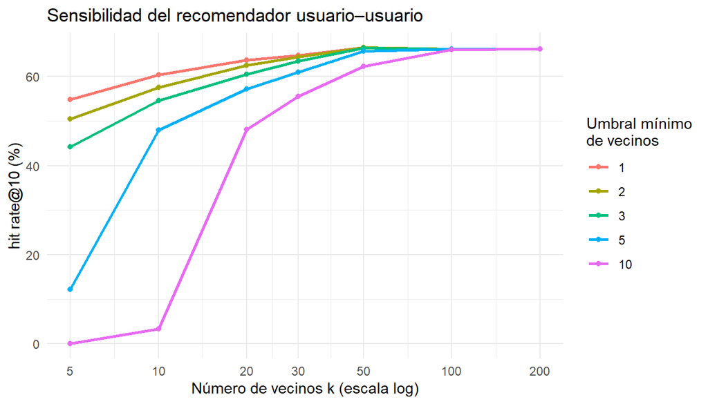

```r
sensibilidad %>%
  ggplot(aes(k, 100 * hit_rate_10, color = factor(min_vecinos))) +
  geom_line(linewidth = 1) + geom_point() +
  scale_x_log10(breaks = ks) +
  labs(x = "Número de vecinos k (escala log)", y = "hit rate@10 (%)",
       color = "Umbral mínimo\nde vecinos",
       title = "Sensibilidad del recomendador usuario–usuario")
```

```r
n_eval <- length(eval_u)
mejor <- sensibilidad %>% slice_max(hit_rate_10, n = 1, with_ties = FALSE)
ee <- sqrt(mejor$hit_rate_10 * (1 - mejor$hit_rate_10) / n_eval)
mejor %>% mutate(ic_inf = hit_rate_10 - 1.96 * ee, ic_sup = hit_rate_10 + 1.96 * ee)
```

```
## # A tibble: 1 × 7
##       k min_vecinos hit_rate_10 precision_10 cobertura ic_inf ic_sup
##   <dbl>       <dbl>       <dbl>        <dbl>     <dbl>  <dbl>  <dbl>
## 1    50           1       0.666        0.125         1  0.647  0.684
```

```r
# combinaciones cuyo hit rate cae dentro del IC 95 % de la mejor
sensibilidad %>%
  filter(hit_rate_10 >= mejor$hit_rate_10 - 1.96 * ee) %>%
  arrange(desc(hit_rate_10)) %>%
  mutate(across(c(hit_rate_10, precision_10, cobertura), ~ round(100 * .x, 1)))
```

```
## # A tibble: 15 × 5
##        k min_vecinos hit_rate_10 precision_10 cobertura
##    <dbl>       <dbl>       <dbl>        <dbl>     <dbl>
##  1    50           1        66.6         12.5     100
##  2    50           2        66.5         12.5     100
##  3    50           3        66.5         12.5      98.8
##  4   100           1        66.2         12.6     100
##  5   100           2        66.2         12.6     100
##  6   100           3        66.2         12.6     100
##  7   200           1        66.2         12.5     100
##  8   200           2        66.2         12.5     100
##  9   200           3        66.2         12.5     100
## 10   200           5        66.2         12.5     100
## 11   200          10        66.2         12.5     100
## 12   100           5        66.2         12.6     100
## 13   100          10        66           12.5      98.5
## 14    50           5        65.8         12.3      95.1
## 15    30           1        64.8         12.2     100
```

### 6.6.1 Lectura y elección

- **Con k pequeño** (5 o 10 vecinos) el recomendador depende de muy pocas personas: el acierto baja y, si además se exige un umbral alto, muchos compradores no alcanzan 10 recomendaciones (baja la cobertura).
- **Con k muy grande** los vecinos dejan de ser parecidos: el promedio se acerca a “lo que compra todo el mundo” y el recomendador se parece a la lista de los más vendidos.
- **El umbral** filtra productos que solo compró un vecino. Con k pequeño un umbral alto vacía la lista; con k grande casi no cambia nada, porque los productos que suben al top ya los compraron muchos vecinos.

La combinación con mayor acierto es k = 50 y umbral = 1, con un hit rate@10 de 66.6 % (IC 95 %: 64.7 a 68.4 %). Las combinaciones con k = 50 y umbral de 1 a 5, y casi todas las de k = 100 y 200, quedan dentro de ese intervalo, así que el acierto no las distingue. **Elegimos k = 50 y umbral = 2**:

- **k = 50** es el menor número de vecinos que alcanza el acierto máximo. Con más vecinos el acierto no mejora y los vecinos son cada vez menos parecidos, así que las recomendaciones se acercan a “lo más vendido”.
- **Umbral = 2** da el mismo acierto y la misma cobertura (100 %) que el umbral 1, pero descarta productos respaldados por un solo vecino. Es más robusto sin costo, y la explicación al usuario (“al menos 2 de 50 compradores parecidos lo compraron”) es más convincente.

Estos son los valores por defecto que usará el prototipo, y la Fase 7 hará la comparación formal con la línea base.

Nota: la evaluación se hizo **sin** la regla de una por familia, para medir el recomendador puro. Esa regla cambia el orden de la lista (da variedad) a cambio de dejar fuera algunas presentaciones; su efecto en el acierto se medirá en la Fase 7.

## 6.7 Resultados para el prototipo

Precalculamos, para cada comprador, sus 10 recomendaciones con la explicación y su historial, que es lo que mostrará la vista «comprador».

```r
recomendaciones_usuario <- bind_rows(lapply(rownames(X), function(cl)
  user_recommendation(cl, k = k_elegido, min_vecinos = m_elegido) %>%
    mutate(colaborador = cl, puesto = row_number(), .before = 1)))

historial_usuario <- datos %>%
  group_by(colaborador, Material) %>%
  summarise(description = first(description), unidades = sum(cantidad),
            facturas = n_distinct(invoice), ultima_compra = max(fecha), .groups = "drop")

recomendaciones_usuario %>% count(colaborador) %>%
  summarise(compradores = n(), con_10 = sum(n == 10), con_menos = sum(n < 10))
```

```
## # A tibble: 1 × 3
##   compradores con_10 con_menos
##         <int>  <int>     <int>
## 1        5888   5863        25
```

```r
saveRDS(list(recomendaciones = recomendaciones_usuario, historial = historial_usuario,
             k = k_elegido, min_vecinos = m_elegido),
        "data/recomendaciones_usuario.rds")
```

# 7 Fase 7 · Evaluación contra la línea base

**Pregunta:** ¿los recomendadores de las Fases 5 y 6 aciertan más que mostrar simplemente los 10 productos más vendidos?

## 7.1 Diseño de la evaluación

- **Partición temporal.** Todo se entrena con las compras hasta el **31/12/2020**: la matriz, las similitudes, los vecinos y la lista de más vendidos. Se prueba con las compras de **2021–2022**. Así el modelo nunca “ve el futuro”, como pasaría en la realidad.
- **Compradores evaluados:** los que compraron en ambos periodos.
- **Acierto:** un producto recomendado es acierto si el comprador lo compró en 2021–2022 **y no lo había comprado antes** (compra nueva). Recomendar algo que ya compra siempre no tiene mérito.
- **Métricas**, con $R_u$ las 10 recomendaciones del comprador $u$ y $N_u$ sus compras nuevas:
  - **hit rate@10** = proporción de compradores con al menos un acierto: $\frac{1}{|U|}\sum_u \mathbb{1}(|R_u \cap N_u| > 0)$
  - **precision@10** = proporción promedio de aciertos en las 10: $\frac{1}{|U|}\sum_u \frac{|R_u \cap N_u|}{10}$
- **Hiperparámetros** fijados en las fases anteriores (definición log, umbral 5 compradores en común, α = 0,25, k = 50, mínimo 2 vecinos). No se ajustan aquí con los datos de prueba.

```r
datos    <- readRDS("data/datos_unidos.rds")
catalogo <- readRDS("data/catalogo.rds")
nombre   <- function(codigo) catalogo$description[match(codigo, catalogo$Material)]
corte    <- as.Date("2020-12-31")

pares <- function(d) d %>% group_by(colaborador, Material) %>%
  summarise(v = log1p(sum(cantidad)), unidades = sum(cantidad), .groups = "drop")
entrena <- pares(filter(datos, fecha <= corte))
prueba  <- pares(filter(datos, fecha >  corte))

productos <- sort(unique(datos$Material))
usu_tr    <- sort(unique(entrena$colaborador))
X_tr <- matrix(0, length(usu_tr), length(productos), dimnames = list(usu_tr, productos))
X_tr[cbind(match(entrena$colaborador, usu_tr), match(entrena$Material, productos))] <- entrena$v
B_tr <- (X_tr > 0) * 1

eval_u <- intersect(usu_tr, unique(prueba$colaborador))
nuevas <- prueba %>% filter(colaborador %in% eval_u) %>%
  anti_join(entrena, by = c("colaborador", "Material"))
verdad <- matrix(0, length(eval_u), length(productos), dimnames = list(eval_u, productos))
verdad[cbind(match(nuevas$colaborador, eval_u), match(nuevas$Material, productos))] <- 1

tibble(indicador = c("Compradores en entrenamiento", "Compradores en prueba",
                     "Compradores en ambos (evaluados)",
                     "Evaluados con al menos una compra nueva",
                     "Compras nuevas (pares comprador-producto)",
                     "Productos que solo existen en 2021-2022"),
       valor = c(length(usu_tr), n_distinct(prueba$colaborador), length(eval_u),
                 sum(rowSums(verdad) > 0), sum(verdad),
                 sum(colSums(B_tr) == 0)))
```

```
## # A tibble: 6 × 2
##   indicador                                 valor
##   <chr>                                     <dbl>
## 1 Compradores en entrenamiento               5255
## 2 Compradores en prueba                      3201
## 3 Compradores en ambos (evaluados)           2568
## 4 Evaluados con al menos una compra nueva    2533
## 5 Compras nuevas (pares comprador-producto) 27901
## 6 Productos que solo existen en 2021-2022      60
```

Nota: hay compradores evaluados que en 2021–2022 solo repitieron productos. Para ellos ningún recomendador puede acertar, pero se incluyen, porque así lo pide la definición (todo comprador presente en ambos periodos). En la sección 4 repetimos el análisis solo con quienes sí hicieron compras nuevas. Los productos lanzados después de 2020 no pueden recomendarse con filtrado colaborativo (nadie los ha comprado en entrenamiento): es una limitación de estos métodos.

## 7.2 Los cinco recomendadores comparados

Cada uno produce una matriz de 10 productos por comprador evaluado. En **todos** se excluyen los productos que el comprador ya compró en entrenamiento, también en la línea base: así la comparación es justa.

```r
top_n_matriz <- function(puntaje, n = 10) {          # índices de los n mejores de cada fila
  t(apply(puntaje, 1, function(z) order(z, decreasing = TRUE)[1:n]))
}
ya_comprado <- B_tr[eval_u, ] > 0
```

**1. Línea base: los 10 más vendidos.** Los 10 productos con más unidades vendidas hasta 2020, saltando los que el comprador ya tiene (si ya tiene alguno, pasa al 11.º, etc.).

```r
ventas_tr <- colSums(expm1(X_tr))                      # unidades vendidas hasta 2020
nombre(names(sort(ventas_tr, decreasing = TRUE))[1:10])
```

```
##  [1] "GINKGO BILOBA 40 mg CBG CJA x20 UND CIAL"
##  [2] "NISTATINA+OXIDO DE ZINC UNGU TUBOx60 g"
##  [3] "VITAMINA E 400 UI FCO x 50 CBG (1+1)"
##  [4] "NUTRIGEL 2.0 SABOR NRJA CJAx30SOBRE CIAL"
##  [5] "VITAMINA E 1000 UI FCO x 30 CBG"
##  [6] "GESTAVIT DHA CBG CAJA x 30 UND CIAL"
##  [7] "CLOTRIMAZOL CREMA TOPICA x 40 g COLMED"
##  [8] "NUTRIGEL 2.0 SABOR NTRO CJAx30SOBRE CIAL"
##  [9] "DOLOFEN JBE FCO x 60ml"
## [10] "VITAMINA E 400 CBG CJA x 100 UND"
```

```r
p_base <- matrix(ventas_tr, length(eval_u), length(productos), byrow = TRUE)
p_base[ya_comprado] <- -Inf
rec_base <- top_n_matriz(p_base)
```

**2 y 3. Ítem–ítem (Fase 5)**, con coseno puro y con la penalización de popularidad α = 0,25. La puntuación de un candidato es la suma de su similitud con los productos del historial, ponderada por la preferencia.

```r
normas <- sqrt(colSums(X_tr^2))
S <- crossprod(X_tr) / outer(normas, normas)
S[is.nan(S)] <- 0
S[crossprod(B_tr) < 5] <- 0                            # umbral de compradores en común
diag(S) <- 0
compradores_tr <- pmax(colSums(B_tr), 1)

recomendar_item <- function(alpha) {
  S_a <- S / matrix(compradores_tr^alpha, nrow(S), ncol(S), byrow = TRUE)
  p <- X_tr[eval_u, ] %*% S_a
  p[ya_comprado] <- -Inf
  top_n_matriz(p)
}
rec_item0  <- recomendar_item(0)
rec_item25 <- recomendar_item(0.25)
```

**4 y 5. Usuario–usuario (Fase 6)** con k = 50 vecinos y mínimo 2 vecinos, sin y con la regla de un producto por familia.

```r
Xn <- X_tr / sqrt(rowSums(X_tr^2))
U  <- Xn[eval_u, ] %*% t(Xn)
U[cbind(seq_along(eval_u), match(eval_u, usu_tr))] <- 0          # sin sí mismo
kth <- apply(U, 1, function(z) sort(z, decreasing = TRUE)[50])
W   <- U * (U >= kth)
p_usu <- (W %*% X_tr) / rowSums(W)
p_usu[((W > 0) %*% B_tr) < 2] <- -Inf                           # mínimo 2 vecinos
p_usu[ya_comprado] <- -Inf
rec_usu <- top_n_matriz(p_usu)

# regla de una por familia (Fase 6)
genericas <- c("VITAMINA", "TIRAS", "ACEITE", "OFERTA", "PROTEKTA")
palabras  <- strsplit(nombre(productos), "\\s+")
familia   <- sapply(palabras, function(p)
  if (p[1] %in% genericas && length(p) > 1) paste(p[1], p[2]) else p[1])

rec_usu_fam <- t(apply(p_usu, 1, function(z) {
  orden <- order(z, decreasing = TRUE)
  orden <- orden[is.finite(z[orden])]
  elegidos <- orden[!duplicated(familia[orden])]
  c(elegidos, rep(NA, 10))[1:10]                     # NA si no hay 10 familias distintas
}))
```

## 7.3 Resultados

```r
aciertos <- function(rec) {                            # matriz comprador × 10 con 1 = acierto
  a <- matrix(verdad[cbind(rep(seq_along(eval_u), 10), as.vector(rec))], ncol = 10)
  a[is.na(a)] <- 0
  a
}

modelos <- list(
  "Línea base: 10 más vendidos"   = rec_base,
  "Ítem–ítem, coseno puro"        = rec_item0,
  "Ítem–ítem, α = 0,25"           = rec_item25,
  "Usuario–usuario, k = 50"       = rec_usu,
  "Usuario–usuario, una por familia" = rec_usu_fam)

por_usuario <- lapply(modelos, function(r) {
  a <- aciertos(r)
  tibble(colaborador = eval_u, hit = as.numeric(rowSums(a) > 0), precision = rowSums(a) / 10)
})
```

### 7.3.1 Intervalos de confianza

- **hit rate@10** es una proporción: usamos el intervalo de **Wilson**, que se comporta bien incluso con proporciones lejanas de 0,5.
- **precision@10** es un promedio por comprador de una variable acotada y asimétrica: usamos **bootstrap** (2.000 remuestreos de compradores, percentiles 2,5 y 97,5).

```r
wilson <- function(x, n, z = 1.96) {
  p <- x / n
  centro <- (p + z^2 / (2 * n)) / (1 + z^2 / n)
  margen <- z * sqrt(p * (1 - p) / n + z^2 / (4 * n^2)) / (1 + z^2 / n)
  c(centro - margen, centro + margen)
}

set.seed(2026)
B <- 2000
idx_boot <- replicate(B, sample.int(length(eval_u), replace = TRUE))

resumen <- bind_rows(lapply(names(por_usuario), function(m) {
  d <- por_usuario[[m]]
  w <- wilson(sum(d$hit), nrow(d))
  boot <- apply(idx_boot, 2, function(i) mean(d$precision[i]))
  tibble(modelo = m,
         hit_rate = mean(d$hit), hr_inf = w[1], hr_sup = w[2],
         precision = mean(d$precision),
         pr_inf = quantile(boot, 0.025), pr_sup = quantile(boot, 0.975))
}))

resumen %>%
  transmute(modelo,
            `hit rate@10 (%)` = round(100 * hit_rate, 1),
            `IC 95 % Wilson` = sprintf("[%.1f, %.1f]", 100 * hr_inf, 100 * hr_sup),
            `precision@10 (%)` = round(100 * precision, 2),
            `IC 95 % bootstrap` = sprintf("[%.2f, %.2f]", 100 * pr_inf, 100 * pr_sup)) %>%
  knitr::kable(align = "lrcrc")
```

| modelo | hit rate@10 (%) | IC 95 % Wilson | precision@10 (%) | IC 95 % bootstrap |
| --- | --- | --- | --- | --- |
| Línea base: 10 más vendidos | 62.5 | [60.6, 64.4] | 11.09 | [10.64, 11.53] |
| Ítem–ítem, coseno puro | 65.3 | [63.4, 67.1] | 12.20 | [11.72, 12.69] |
| Ítem–ítem, α = 0,25 | 64.5 | [62.7, 66.4] | 12.17 | [11.68, 12.63] |
| Usuario–usuario, k = 50 | 65.6 | [63.8, 67.4] | 12.32 | [11.84, 12.80] |
| Usuario–usuario, una por familia | 64.6 | [62.7, 66.4] | 12.01 | [11.53, 12.47] |

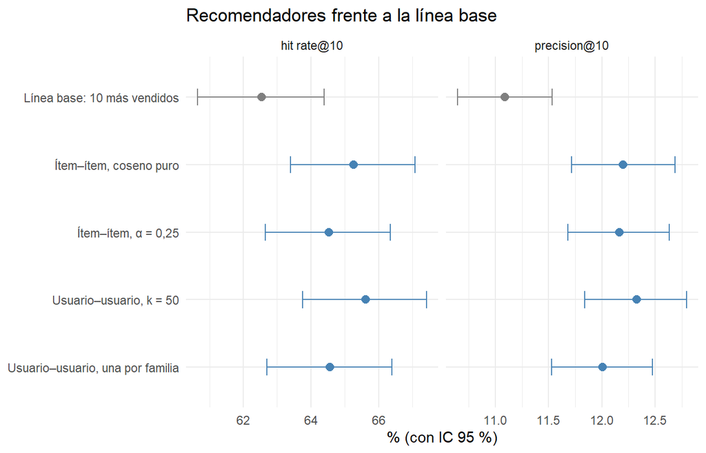

```r
bind_rows(
  resumen %>% transmute(modelo, metrica = "hit rate@10", valor = hit_rate, inf = hr_inf, sup = hr_sup),
  resumen %>% transmute(modelo, metrica = "precision@10", valor = precision, inf = pr_inf, sup = pr_sup)
) %>%
  mutate(base = grepl("base", modelo),
         modelo = factor(modelo, levels = rev(names(modelos)))) %>%
  ggplot(aes(100 * valor, modelo, color = base)) +
  geom_errorbarh(aes(xmin = 100 * inf, xmax = 100 * sup), height = 0.25) +
  geom_point(size = 2.5) +
  facet_wrap(~ metrica, scales = "free_x") +
  scale_color_manual(values = c(`TRUE` = "grey50", `FALSE` = "steelblue"), guide = "none") +
  labs(x = "% (con IC 95 %)", y = NULL, title = "Recomendadores frente a la línea base")
```

### 7.3.2 ¿La diferencia con la línea base es significativa?

- Para el **hit rate**: prueba de **McNemar**, que solo mira a los compradores en los que los dos métodos difieren (uno acierta y el otro no).
- Para la **precision**: diferencia promedio por comprador con IC **bootstrap pareado** y prueba de **Wilcoxon** de rangos con signo.

```r
base <- por_usuario[["Línea base: 10 más vendidos"]]

comparacion <- bind_rows(lapply(names(modelos)[-1], function(m) {
  d <- por_usuario[[m]]
  tabla <- table(factor(d$hit, 0:1), factor(base$hit, 0:1))
  dif   <- d$precision - base$precision
  boot  <- apply(idx_boot, 2, function(i) mean(dif[i]))
  tibble(modelo = m,
         `solo el modelo acierta` = tabla["1", "0"],
         `solo la base acierta`   = tabla["0", "1"],
         `dif. hit rate (pp)`     = round(100 * (mean(d$hit) - mean(base$hit)), 1),
         `p McNemar`              = format.pval(mcnemar.test(tabla)$p.value, eps = 1e-10, digits = 3),
         p_mcnemar                = mcnemar.test(tabla)$p.value,
         `dif. precision (pp)`    = round(100 * mean(dif), 2),
         `IC 95 % dif. precision` = sprintf("[%.2f, %.2f]", 100 * quantile(boot, 0.025),
                                            100 * quantile(boot, 0.975)),
         `p Wilcoxon`             = format.pval(wilcox.test(d$precision, base$precision,
                                                            paired = TRUE)$p.value,
                                                eps = 1e-10, digits = 3))
}))
knitr::kable(select(comparacion, -p_mcnemar))
```

| modelo | solo el modelo acierta | solo la base acierta | dif. hit rate (pp) | p McNemar | dif. precision (pp) | IC 95 % dif. precision | p Wilcoxon |
| --- | --- | --- | --- | --- | --- | --- | --- |
| Ítem–ítem, coseno puro | 143 | 73 | 2.7 | 2.67e-06 | 1.11 | [0.89, 1.33] | <1e-10 |
| Ítem–ítem, α = 0,25 | 230 | 179 | 2.0 | 0.0134 | 1.08 | [0.75, 1.40] | <1e-10 |
| Usuario–usuario, k = 50 | 221 | 142 | 3.1 | 4.24e-05 | 1.24 | [0.93, 1.55] | <1e-10 |
| Usuario–usuario, una por familia | 231 | 179 | 2.0 | 0.0118 | 0.92 | [0.60, 1.22] | 1.47e-07 |

## 7.4 Solo compradores con compras nuevas

Los compradores que no hicieron ninguna compra nueva tienen 0 aciertos con cualquier método. Quitarlos no cambia la comparación, pero muestra el acierto entre quienes sí tenían algo nuevo que descubrir:

```r
con_nuevas <- rowSums(verdad) > 0
bind_rows(lapply(names(por_usuario), function(m) {
  d <- por_usuario[[m]][con_nuevas, ]
  w <- wilson(sum(d$hit), nrow(d))
  tibble(modelo = m, compradores = nrow(d),
         `hit rate@10 (%)` = round(100 * mean(d$hit), 1),
         `IC 95 %` = sprintf("[%.1f, %.1f]", 100 * w[1], 100 * w[2]),
         `precision@10 (%)` = round(100 * mean(d$precision), 2))
})) %>% knitr::kable()
```

| modelo | compradores | hit rate@10 (%) | IC 95 % | precision@10 (%) |
| --- | --- | --- | --- | --- |
| Línea base: 10 más vendidos | 2533 | 63.4 | [61.5, 65.3] | 11.24 |
| Ítem–ítem, coseno puro | 2533 | 66.2 | [64.3, 68.0] | 12.37 |
| Ítem–ítem, α = 0,25 | 2533 | 65.4 | [63.5, 67.2] | 12.33 |
| Usuario–usuario, k = 50 | 2533 | 66.5 | [64.7, 68.3] | 12.50 |
| Usuario–usuario, una por familia | 2533 | 65.5 | [63.6, 67.3] | 12.17 |

## 7.5 ¿Qué tan distintas son las recomendaciones de la línea base?

Un recomendador podría acertar mucho solo por repetir los más vendidos. Medimos la **cobertura del catálogo** (cuántos productos distintos recomienda en total) y qué parte de sus recomendaciones son productos del top 10:

```r
top10_tr <- names(sort(ventas_tr, decreasing = TRUE))[1:10]
bind_rows(lapply(names(modelos), function(m) {
  r <- as.vector(modelos[[m]]); r <- r[!is.na(r)]
  tibble(modelo = m,
         `productos distintos recomendados` = n_distinct(r),
         `% del catálogo` = round(100 * n_distinct(r) / length(productos), 1),
         `% de recomendaciones del top 10` = round(100 * mean(productos[r] %in% top10_tr), 1))
})) %>% knitr::kable()
```

| modelo | productos distintos recomendados | % del catálogo | % de recomendaciones del top 10 |
| --- | --- | --- | --- |
| Línea base: 10 más vendidos | 76 | 10.4 | 45.5 |
| Ítem–ítem, coseno puro | 115 | 15.7 | 34.5 |
| Ítem–ítem, α = 0,25 | 263 | 35.9 | 24.3 |
| Usuario–usuario, k = 50 | 166 | 22.7 | 31.8 |
| Usuario–usuario, una por familia | 182 | 24.9 | 27.8 |

## 7.6 Conclusión

1. **Todos los recomendadores superan a la línea base de forma estadísticamente significativa** en las dos métricas. Los 10 más vendidos aciertan con al menos un producto nuevo en el 62.5 % de los compradores; el usuario–usuario llega al 65.6 % (McNemar p = 4.2e-05) y el ítem–ítem con coseno puro al 65.3 % (p = 2.7e-06). Ningún intervalo de la diferencia en precision@10 incluye el 0.
2. **La mejora es modesta: 2 a 3 puntos.** La línea base es exigente en este mercado: pocos productos concentran las ventas (Fase 2), así que “lo más vendido” ya acierta mucho. El valor del recomendador no está solo en acertar algo más, sino en **acertar con productos distintos**.
3. **La diversidad sí cambia mucho.** La línea base recomienda solo 76 productos distintos, y casi la mitad de sus recomendaciones son del top 10. El ítem–ítem con α = 0,25 recomienda 36 % del catálogo con el mismo acierto que los demás recomendadores; es decir, personaliza sin perder precisión.
4. Las dos variantes “más amables con el usuario” (α = 0,25 en ítem–ítem y una por familia en usuario–usuario) aciertan un punto menos que sus versiones puras, pero **siguen superando a la línea base** (p = 1.3e-02 y p = 1.2e-02) y dan listas más variadas y con más sentido farmacéutico (Fase 5).

**Decisión para el prototipo:**

- **Vista «producto»:** ítem–ítem con α = 0,25. Es la que mejor se entiende (“quienes compran X también compran Y”) y la más diversa.
- **Vista «comprador»:** usuario–usuario con k = 50, mínimo 2 vecinos y una por familia. Supera a la línea base y evita listas llenas de presentaciones del mismo producto.

**Limitaciones para el informe:** la mejora sobre la línea base es pequeña en términos absolutos; la evaluación mide compras, no satisfacción (un producto no comprado pudo ser una buena sugerencia); los 60 productos lanzados después de 2020 no pueden recomendarse con filtrado colaborativo, y un comprador sin historial no recibe recomendaciones personalizadas (arranque en frío), para quien la línea base sigue siendo la mejor opción.